# 1.Polars_to_read_Data

```python
import polars as pl
import pandas as pd
import datetime as dt
```

```python
from plotnine import *
```

### mf

```python
multifamily_df_head = pl.read_csv(r'MultiFamily Loan Performance Data\Multifamily\FNMA_MF_Loan_Performance_Data_202212.csv',
            n_rows=10, try_parse_dates=True)

multifamily_df_head
```

shape: (10, 62)

| Loan Number i64 | Acquisition Date date | Note Date date | Maturity Date at Acquisition date | Loan Acquisition UPB str | Amortization Type str | Interest Type str | Loan Product Type str | Original UPB str | Amortization Term i64 | Original Interest Rate f64 | Lien Position str | Transaction ID i64 | Issue Date date | Loan Acquisition LTV f64 | Underwritten DSCR f64 | Underwritten DSCR Type str | Original Term i64 | Original I/O Term str | I/O End Date str | Loan Ever 60+ Days Delinquent str | Loss Sharing Type str | Modified Loss Sharing Percentage str | Number of Properties at Acquisition i64 | Property Acquisition Total Unit Count i64 | Specific Property Type str | Year Built i64 | Property City str | Property State str | Property Zip Code i64 | … |
| --- | --- | --- | --- | --- | --- | --- | --- | --- | --- | --- | --- | --- | --- | --- | --- | --- | --- | --- | --- | --- | --- | --- | --- | --- | --- | --- | --- | --- | --- | --- |
| 140296 | 2000-10-31 | 1985-07-16 | 2001-08-10 | "$82,501.71" | null | "ARM" | "DUS" | "$82,501.71" | null | 5.196 | "First" | null | null | 50.0 | null | null | 360 | null | null | "Y" | null | null | 1 | 4 | "Multifamily" | null | "SAN DIEGO" | "CA" | 92102 | … |
| 140296 | 2000-10-31 | 1985-07-16 | 2001-08-10 | "$82,501.71" | null | "ARM" | "DUS" | "$82,501.71" | null | 5.196 | "First" | null | null | 50.0 | null | null | 360 | null | null | "Y" | null | null | 1 | 4 | "Multifamily" | null | "SAN DIEGO" | "CA" | 92102 | … |
| 140296 | 2000-10-31 | 1985-07-16 | 2001-08-10 | "$82,501.71" | null | "ARM" | "DUS" | "$82,501.71" | null | 5.196 | "First" | null | null | 50.0 | null | null | 360 | null | null | "Y" | null | null | 1 | 4 | "Multifamily" | null | "SAN DIEGO" | "CA" | 92102 | … |
| 140296 | 2000-10-31 | 1985-07-16 | 2001-08-10 | "$82,501.71" | null | "ARM" | "DUS" | "$82,501.71" | null | 5.196 | "First" | null | null | 50.0 | null | null | 360 | null | null | "Y" | null | null | 1 | 4 | "Multifamily" | null | "SAN DIEGO" | "CA" | 92102 | … |
| 140297 | 2000-10-31 | 1985-07-18 | 2001-08-10 | "$548,872.98" | null | "ARM" | "DUS" | "$548,872.98" | null | 5.196 | "First" | null | null | 50.0 | null | null | 360 | null | null | "Y" | null | null | 1 | 2 | "Multifamily" | null | "SAN DIEGO" | "CA" | 92116 | … |
| 140297 | 2000-10-31 | 1985-07-18 | 2001-08-10 | "$548,872.98" | null | "ARM" | "DUS" | "$548,872.98" | null | 5.196 | "First" | null | null | 50.0 | null | null | 360 | null | null | "Y" | null | null | 1 | 2 | "Multifamily" | null | "SAN DIEGO" | "CA" | 92116 | … |
| 140297 | 2000-10-31 | 1985-07-18 | 2001-08-10 | "$548,872.98" | null | "ARM" | "DUS" | "$548,872.98" | null | 5.196 | "First" | null | null | 50.0 | null | null | 360 | null | null | "Y" | null | null | 1 | 2 | "Multifamily" | null | "SAN DIEGO" | "CA" | 92116 | … |
| 140297 | 2000-10-31 | 1985-07-18 | 2001-08-10 | "$548,872.98" | null | "ARM" | "DUS" | "$548,872.98" | null | 5.196 | "First" | null | null | 50.0 | null | null | 360 | null | null | "Y" | null | null | 1 | 2 | "Multifamily" | null | "SAN DIEGO" | "CA" | 92116 | … |
| 1673867584 | 2000-01-01 | 1999-11-01 | 2009-12-01 | "$14,725,385.83… | "Amortizing Bal… | "Fixed" | "DUS" | "$14,736,000.00… | 360 | 7.649 | "First" | 382113 | 2000-01-01 | 80.0 | 1.25 | "Lender UW DSCR… | 120 | null | null | "N" | null | null | 1 | 408 | "Multifamily" | 1985 | "ARLINGTON" | "TX" | 76017 | … |
| 1673867584 | 2000-01-01 | 1999-11-01 | 2009-12-01 | "$14,725,385.83… | "Amortizing Bal… | "Fixed" | "DUS" | "$14,736,000.00… | 360 | 7.649 | "First" | 382113 | 2000-01-01 | 80.0 | 1.25 | "Lender UW DSCR… | 120 | null | null | "N" | null | null | 1 | 408 | "Multifamily" | 1985 | "ARLINGTON" | "TX" | 76017 | … |

### scan, schema, dim

```python
mf_df_scan = pl.scan_csv(r'V:\Credit Risk Modeling fannie Mae data\MultiFamily Loan Performance Data\Multifamily\FNMA_MF_Loan_Performance_Data_202212.csv',
                         try_parse_dates=True)
mf_df_scan
```

NAIVE QUERY PLAN

run **LazyFrame.show_graph()** to see the optimized version

```python
mf_df_scan.schema
```

```
{'Loan Number': Int64,
 'Acquisition Date': Date,
 'Note Date': Date,
 'Maturity Date at Acquisition': Date,
 'Loan Acquisition UPB': Utf8,
 'Amortization Type': Utf8,
 'Interest Type': Utf8,
 'Loan Product Type': Utf8,
 'Original UPB': Utf8,
 'Amortization Term': Int64,
 'Original Interest Rate': Float64,
 'Lien Position': Utf8,
 'Transaction ID ': Int64,
 'Issue Date': Date,
 'Loan Acquisition LTV': Float64,
 'Underwritten DSCR': Float64,
 'Underwritten DSCR Type': Utf8,
 'Original Term': Int64,
 'Original I/O Term': Utf8,
 'I/O End Date': Utf8,
 'Loan Ever 60+ Days Delinquent': Utf8,
 'Loss Sharing Type': Utf8,
 'Modified Loss Sharing Percentage': Utf8,
 'Number of Properties at Acquisition': Int64,
 'Property Acquisition Total Unit Count': Int64,
 'Specific Property Type': Utf8,
 'Year Built': Int64,
 'Property City': Utf8,
 'Property State': Utf8,
 'Property Zip Code': Int64,
 'Metropolitan Statistical Area': Utf8,
 'Physical Occupancy %': Float64,
 'Liquidation/Prepayment Code': Utf8,
 'Liquidation/Prepayment Date': Date,
 'Foreclosure Date': Utf8,
 'Credit Event Date': Utf8,
 'Foreclosure Value': Utf8,
 'Lifetime Net Credit Loss Amount': Utf8,
 'Sale Price': Utf8,
 'Default Amount': Utf8,
 'Credit Event Type': Utf8,
 'Reporting Period Date': Date,
 'Loan Active Property Count': Int64,
 'Note Rate': Float64,
 'Maturity Date - Current': Date,
 'UPB - Current': Utf8,
 'Delinquency UPB': Utf8,
 'Loan Payment Status': Utf8,
 'SDQ Indicator': Utf8,
 'Most Recent Modification Date': Utf8,
 'Modification Indicator': Utf8,
 'Defeasance Date': Utf8,
 'Prepayment Provision': Utf8,
 'Prepayment Provision End Date': Utf8,
 'Affordable Housing Type': Utf8,
 'MCIRT Deal ID': Utf8,
 'MCAS Deal ID': Utf8,
 'DUS Prepayment Outcomes': Utf8,
 'DUS Prepayment Segments': Utf8,
 'Loan Age': Int64,
 'Green Bond Indicator': Utf8,
 'Social Bond Indicator': Utf8}
```

```python
print(mf_df_scan.schema)
```

```
{'Loan Number': Int64, 'Acquisition Date': Date, 'Note Date': Date, 'Maturity Date at Acquisition': Date, 'Loan Acquisition UPB': Utf8, 'Amortization Type': Utf8, 'Interest Type': Utf8, 'Loan Product Type': Utf8, 'Original UPB': Utf8, 'Amortization Term': Int64, 'Original Interest Rate': Float64, 'L…
```

```python
# below code gave an error
# mf_df_scan.slice(1000000, 5).collect()
```

```python
mf_df_scan.select(pl.count()).collect()
```

shape: (1, 1)

| count u32 |
| --- |
| 4310951 |

```python
mf_df_scan.columns.__len__()
```

```
62
```

```python
# this doesn't work
# mf_df_scan.tail().collect()
```

```python
mf_df_scan.slice(4310945,10).collect()
```

| 8300008176 i64 | 2021-02-25 date | 2021-02-25_duplicated_0 date | 2051-02-01 date | $16,400,000.00 str | Interest Only/Amortizing/Balloon str | Fixed str | Non-DUS str | $16,400,000.00_duplicated_0 str | 480 i64 | 4.13 f64 | First str | str | _duplicated_0 str | 62.4 f64 | 1.18 f64 | UW DSCR NCF str | 360 i64 | 24 i64 | 2023-02-01 date | N str | Pari Passu str | _duplicated_1 str | 1 i64 | 102 i64 | Multifamily str | 1925 i64 | NEW YORK str | NY str | 10027 i64 | … |
| --- | --- | --- | --- | --- | --- | --- | --- | --- | --- | --- | --- | --- | --- | --- | --- | --- | --- | --- | --- | --- | --- | --- | --- | --- | --- | --- | --- | --- | --- | --- |
| 8300008176 | 2021-02-25 | 2021-02-25 | 2051-02-01 | "$16,400,000.00… | "Interest Only/… | "Fixed" | "Non-DUS" | "$16,400,000.00… | 480 | 4.13 | "First" | null | null | 62.4 | 1.18 | "UW DSCR NCF" | 360 | 24 | 2023-02-01 | "N" | "Pari Passu" | null | 1 | 102 | "Multifamily" | 1925 | "NEW YORK" | "NY" | 10027 | … |
| 8300008176 | 2021-02-25 | 2021-02-25 | 2051-02-01 | "$16,400,000.00… | "Interest Only/… | "Fixed" | "Non-DUS" | "$16,400,000.00… | 480 | 4.13 | "First" | null | null | 62.4 | 1.18 | "UW DSCR NCF" | 360 | 24 | 2023-02-01 | "N" | "Pari Passu" | null | 1 | 102 | "Multifamily" | 1925 | "NEW YORK" | "NY" | 10027 | … |
| 8300008176 | 2021-02-25 | 2021-02-25 | 2051-02-01 | "$16,400,000.00… | "Interest Only/… | "Fixed" | "Non-DUS" | "$16,400,000.00… | 480 | 4.13 | "First" | null | null | 62.4 | 1.18 | "UW DSCR NCF" | 360 | 24 | 2023-02-01 | "N" | "Pari Passu" | null | 1 | 102 | "Multifamily" | 1925 | "NEW YORK" | "NY" | 10027 | … |
| 8300008176 | 2021-02-25 | 2021-02-25 | 2051-02-01 | "$16,400,000.00… | "Interest Only/… | "Fixed" | "Non-DUS" | "$16,400,000.00… | 480 | 4.13 | "First" | null | null | 62.4 | 1.18 | "UW DSCR NCF" | 360 | 24 | 2023-02-01 | "N" | "Pari Passu" | null | 1 | 102 | "Multifamily" | 1925 | "NEW YORK" | "NY" | 10027 | … |
| 8300008176 | 2021-02-25 | 2021-02-25 | 2051-02-01 | "$16,400,000.00… | "Interest Only/… | "Fixed" | "Non-DUS" | "$16,400,000.00… | 480 | 4.13 | "First" | null | null | 62.4 | 1.18 | "UW DSCR NCF" | 360 | 24 | 2023-02-01 | "N" | "Pari Passu" | null | 1 | 102 | "Multifamily" | 1925 | "NEW YORK" | "NY" | 10027 | … |
| 8300008176 | 2021-02-25 | 2021-02-25 | 2051-02-01 | "$16,400,000.00… | "Interest Only/… | "Fixed" | "Non-DUS" | "$16,400,000.00… | 480 | 4.13 | "First" | null | null | 62.4 | 1.18 | "UW DSCR NCF" | 360 | 24 | 2023-02-01 | "N" | "Pari Passu" | null | 1 | 102 | "Multifamily" | 1925 | "NEW YORK" | "NY" | 10027 | … |

Common Error Common Error Received in all below codes in this notebook is due to data type Reading Issue in Transaction id column:

ComputeError Traceback (most recent call last) Cell In[83], line 1 ----> 1 mf_df_scan3.select(pl.col('Transaction ID ').unique()).collect()

ComputeError: Could not parse `AM8698` as dtype `i64` at column 'Transaction ID ' (column number 13). The current offset in the file is 1038775240 bytes.

You might want to try:

- increasing `infer_schema_length` (e.g. `infer_schema_length=10000`),
- specifying correct dtype with the `dtypes` argument
- setting `ignore_errors` to `True`,
- adding `AM8698` to the `null_values` list.

```python
# Gives Error

# mf_df_scan.filter(pl.col('Acquisition Date') > pl.date(2020,12,31)).head().collect()
# mf_df_scan.filter(pl.col('Acquisition Date') > dt.date(2021,5,31)).head().collect()
# mf_df_scan.filter(pl.col('Acquisition Date') > dt.date(2021,5,31)).head().collect()
```

```python
pl.date(2020,12,1)
```

2020.datetime([12, 1, 0, 0, 0, 0]).alias("datetime").strict_cast(Date).alias("date")

```python
dt.datetime(2020,12,1)
```

```
datetime.datetime(2020, 12, 1, 0, 0)
```

#### filter by date

```python
multifamily_df_head.filter(pl.col('Acquisition Date') > dt.date(2000,10,30))
```

shape: (8, 62)

| Loan Number i64 | Acquisition Date date | Note Date date | Maturity Date at Acquisition date | Loan Acquisition UPB str | Amortization Type str | Interest Type str | Loan Product Type str | Original UPB str | Amortization Term i64 | Original Interest Rate f64 | Lien Position str | Transaction ID i64 | Issue Date date | Loan Acquisition LTV f64 | Underwritten DSCR f64 | Underwritten DSCR Type str | Original Term i64 | Original I/O Term str | I/O End Date str | Loan Ever 60+ Days Delinquent str | Loss Sharing Type str | Modified Loss Sharing Percentage str | Number of Properties at Acquisition i64 | Property Acquisition Total Unit Count i64 | Specific Property Type str | Year Built i64 | Property City str | Property State str | Property Zip Code i64 | … |
| --- | --- | --- | --- | --- | --- | --- | --- | --- | --- | --- | --- | --- | --- | --- | --- | --- | --- | --- | --- | --- | --- | --- | --- | --- | --- | --- | --- | --- | --- | --- |
| 140296 | 2000-10-31 | 1985-07-16 | 2001-08-10 | "$82,501.71" | null | "ARM" | "DUS" | "$82,501.71" | null | 5.196 | "First" | null | null | 50.0 | null | null | 360 | null | null | "Y" | null | null | 1 | 4 | "Multifamily" | null | "SAN DIEGO" | "CA" | 92102 | … |
| 140296 | 2000-10-31 | 1985-07-16 | 2001-08-10 | "$82,501.71" | null | "ARM" | "DUS" | "$82,501.71" | null | 5.196 | "First" | null | null | 50.0 | null | null | 360 | null | null | "Y" | null | null | 1 | 4 | "Multifamily" | null | "SAN DIEGO" | "CA" | 92102 | … |
| 140296 | 2000-10-31 | 1985-07-16 | 2001-08-10 | "$82,501.71" | null | "ARM" | "DUS" | "$82,501.71" | null | 5.196 | "First" | null | null | 50.0 | null | null | 360 | null | null | "Y" | null | null | 1 | 4 | "Multifamily" | null | "SAN DIEGO" | "CA" | 92102 | … |
| 140296 | 2000-10-31 | 1985-07-16 | 2001-08-10 | "$82,501.71" | null | "ARM" | "DUS" | "$82,501.71" | null | 5.196 | "First" | null | null | 50.0 | null | null | 360 | null | null | "Y" | null | null | 1 | 4 | "Multifamily" | null | "SAN DIEGO" | "CA" | 92102 | … |
| 140297 | 2000-10-31 | 1985-07-18 | 2001-08-10 | "$548,872.98" | null | "ARM" | "DUS" | "$548,872.98" | null | 5.196 | "First" | null | null | 50.0 | null | null | 360 | null | null | "Y" | null | null | 1 | 2 | "Multifamily" | null | "SAN DIEGO" | "CA" | 92116 | … |
| 140297 | 2000-10-31 | 1985-07-18 | 2001-08-10 | "$548,872.98" | null | "ARM" | "DUS" | "$548,872.98" | null | 5.196 | "First" | null | null | 50.0 | null | null | 360 | null | null | "Y" | null | null | 1 | 2 | "Multifamily" | null | "SAN DIEGO" | "CA" | 92116 | … |
| 140297 | 2000-10-31 | 1985-07-18 | 2001-08-10 | "$548,872.98" | null | "ARM" | "DUS" | "$548,872.98" | null | 5.196 | "First" | null | null | 50.0 | null | null | 360 | null | null | "Y" | null | null | 1 | 2 | "Multifamily" | null | "SAN DIEGO" | "CA" | 92116 | … |
| 140297 | 2000-10-31 | 1985-07-18 | 2001-08-10 | "$548,872.98" | null | "ARM" | "DUS" | "$548,872.98" | null | 5.196 | "First" | null | null | 50.0 | null | null | 360 | null | null | "Y" | null | null | 1 | 2 | "Multifamily" | null | "SAN DIEGO" | "CA" | 92116 | … |

#### Amotization Type

```python
print(
    mf_df_scan
    .select(['Amortization Type'])
    .unique()
    .collect()
)
```

```
shape: (6, 1)
┌──────────────────────────────────┐
│ Amortization Type                │
│ ---                              │
│ str                              │
╞══════════════════════════════════╡
│ Interest Only/Balloon            │
│ Interest Only/Fully Amortizing   │
│ Amortizing Balloon               │
│ Interest Only/Amortizing/Balloon │
│ null                             │
│ Fully Amortizing                 │
└──────────────────────────────────┘
```

#### Interest Type

```python
print(
    mf_df_scan
    .select(['Interest Type'])
    .unique()
    .collect()
)
```

```
shape: (2, 1)
┌───────────────┐
│ Interest Type │
│ ---           │
│ str           │
╞═══════════════╡
│ ARM           │
│ Fixed         │
└───────────────┘
```

#### Loan Product Type

```python
print(
    mf_df_scan
    .select(['Loan Product Type'])
    .unique()
    .collect()
)
```

```
shape: (4, 1)
┌───────────────────┐
│ Loan Product Type │
│ ---               │
│ str               │
╞═══════════════════╡
│ Credit Facility   │
│ DUS               │
│ Bulk Delivery     │
│ Non-DUS           │
└───────────────────┘
```

#### Amortization Term

```python
print(
    mf_df_scan
    .select(['Amortization Term'])
    .unique()
    .collect()
)
```

```
shape: (222, 1)
┌───────────────────┐
│ Amortization Term │
│ ---               │
│ i64               │
╞═══════════════════╡
│ 160               │
│ 112               │
│ 272               │
│ 96                │
│ …                 │
│ 143               │
│ 239               │
│ 31                │
│ 319               │
└───────────────────┘
```

#### Lien Position

```python
print(
    mf_df_scan
    .select(['Lien Position'])
    .unique()
    .collect()
)
```

```
shape: (5, 1)
┌────────────────────────────┐
│ Lien Position              │
│ ---                        │
│ str                        │
╞════════════════════════════╡
│ Third                      │
│ First                      │
│ null                       │
│ Second                     │
│ Fourth or More Subordinate │
└────────────────────────────┘
```

#### State City

```python
print(
    mf_df_scan
    .groupby('Property State','Property City')
    .count()
    .sort('count', descending = True)
    .collect()
)
```

```
shape: (4_621, 3)
┌─────────────────────┬─────────────────────┬────────┐
│ Property State      ┆ Property City       ┆ count  │
│ ---                 ┆ ---                 ┆ ---    │
│ str                 ┆ str                 ┆ u32    │
╞═════════════════════╪═════════════════════╪════════╡
│ CA                  ┆ LOS ANGELES         ┆ 125049 │
│ NY                  ┆ NEW YORK            ┆ 113798 │
│ Multiple Properties ┆ Multiple Properties ┆ 89280  │
│ TX                  ┆ HOUSTON             ┆ 65953  │
│ …                   ┆ …                   ┆ …      │
│ GA                  ┆ GRAY                ┆ 1      │
│ PA                  ┆ SAINT MARYS         ┆ 1      │
│ TN                  ┆ MILLINGTON          ┆ 1      │
│ MI                  ┆ MARCELLUS           ┆ 1      │
└─────────────────────┴─────────────────────┴────────┘
```

#### Liquidation/Prepayment Code

```python
print(
    mf_df_scan
    .select(pl.col('Liquidation/Prepayment Code').value_counts().sort(descending=True))
    .collect()
)
```

```
shape: (12, 1)
┌─────────────────────────────┐
│ Liquidation/Prepayment Code │
│ ---                         │
│ struct[2]                   │
╞═════════════════════════════╡
│ {"Third Party Sale",71}     │
│ {"Substitution",1}          │
│ {"Repurchase",22}           │
│ {"Other Liquidation",69}    │
│ …                           │
│ {"Dissolution",41}          │
│ {"Discounted Payoff",11}    │
│ {"Deed-in-Lieu",26}         │
│ {null,4273115}              │
└─────────────────────────────┘
```

```python
print(
    mf_df_scan
    .select(pl.col('Liquidation/Prepayment Code').head().value_counts())
    .collect()
    .schema
)
```

```
{'Liquidation/Prepayment Code': Struct([Field('Liquidation/Prepayment Code', Utf8), Field('counts', UInt32)])}
```

```python
print(
    mf_df_scan
    .select(pl.col('Liquidation/Prepayment Code').value_counts())
    .collect()
    .unnest(['Liquidation/Prepayment Code'])
    .sort('counts',descending=True)
)
```

```
shape: (12, 2)
┌─────────────────────────────┬─────────┐
│ Liquidation/Prepayment Code ┆ counts  │
│ ---                         ┆ ---     │
│ str                         ┆ u32     │
╞═════════════════════════════╪═════════╡
│ null                        ┆ 4273115 │
│ Fully Paid, Prepaid         ┆ 33568   │
│ Fully Paid, Matured         ┆ 2744    │
│ Fully Paid, Refinanced      ┆ 671     │
│ …                           ┆ …       │
│ Deed-in-Lieu                ┆ 26      │
│ Repurchase                  ┆ 22      │
│ Discounted Payoff           ┆ 11      │
│ Substitution                ┆ 1       │
└─────────────────────────────┴─────────┘
```

```python
print(
    mf_df_scan
    .select(pl.col('Liquidation/Prepayment Code').unique())
    .collect()
)
```

```
shape: (12, 1)
┌─────────────────────────────┐
│ Liquidation/Prepayment Code │
│ ---                         │
│ str                         │
╞═════════════════════════════╡
│ Dissolution                 │
│ null                        │
│ Substitution                │
│ Third Party Sale            │
│ …                           │
│ Fully Paid, Refinanced      │
│ Fully Paid, Prepaid         │
│ Other Liquidation           │
│ Discounted Payoff           │
└─────────────────────────────┘
```

#### Loan Payment Status

```python
print(
    mf_df_scan
    .select(pl.col('Loan Payment Status').value_counts().sort(descending=True))
    .collect()
    .unnest('Loan Payment Status')
)
```

```
shape: (4, 2)
┌───────────────────────┬─────────┐
│ Loan Payment Status   ┆ counts  │
│ ---                   ┆ ---     │
│ str                   ┆ u32     │
╞═══════════════════════╪═════════╡
│ Current               ┆ 4291441 │
│ 90+ Days Delinquent   ┆ 12100   │
│ 60-89 Days Delinquent ┆ 2522    │
│ 30-59 Days Delinquent ┆ 4888    │
└───────────────────────┴─────────┘
```

### scan2

```python
mf_df_scan2 = pl.scan_csv(r'MultiFamily Loan Performance Data\Multifamily\FNMA_MF_Loan_Performance_Data_202212.csv',
                          infer_schema_length=1000000)
mf_df_scan2.head().collect()
```

shape: (5, 62)

| Loan Number i64 | Acquisition Date str | Note Date str | Maturity Date at Acquisition str | Loan Acquisition UPB str | Amortization Type str | Interest Type str | Loan Product Type str | Original UPB str | Amortization Term i64 | Original Interest Rate f64 | Lien Position str | Transaction ID i64 | Issue Date str | Loan Acquisition LTV f64 | Underwritten DSCR f64 | Underwritten DSCR Type str | Original Term i64 | Original I/O Term i64 | I/O End Date str | Loan Ever 60+ Days Delinquent str | Loss Sharing Type str | Modified Loss Sharing Percentage f64 | Number of Properties at Acquisition i64 | Property Acquisition Total Unit Count i64 | Specific Property Type str | Year Built str | Property City str | Property State str | Property Zip Code str | … |
| --- | --- | --- | --- | --- | --- | --- | --- | --- | --- | --- | --- | --- | --- | --- | --- | --- | --- | --- | --- | --- | --- | --- | --- | --- | --- | --- | --- | --- | --- | --- |
| 140296 | "2000-10-31" | "1985-07-16" | "2001-08-10" | "$82,501.71" | null | "ARM" | "DUS" | "$82,501.71" | null | 5.196 | "First" | null | null | 50.0 | null | null | 360 | null | null | "Y" | null | null | 1 | 4 | "Multifamily" | null | "SAN DIEGO" | "CA" | "92102" | … |
| 140296 | "2000-10-31" | "1985-07-16" | "2001-08-10" | "$82,501.71" | null | "ARM" | "DUS" | "$82,501.71" | null | 5.196 | "First" | null | null | 50.0 | null | null | 360 | null | null | "Y" | null | null | 1 | 4 | "Multifamily" | null | "SAN DIEGO" | "CA" | "92102" | … |
| 140296 | "2000-10-31" | "1985-07-16" | "2001-08-10" | "$82,501.71" | null | "ARM" | "DUS" | "$82,501.71" | null | 5.196 | "First" | null | null | 50.0 | null | null | 360 | null | null | "Y" | null | null | 1 | 4 | "Multifamily" | null | "SAN DIEGO" | "CA" | "92102" | … |
| 140296 | "2000-10-31" | "1985-07-16" | "2001-08-10" | "$82,501.71" | null | "ARM" | "DUS" | "$82,501.71" | null | 5.196 | "First" | null | null | 50.0 | null | null | 360 | null | null | "Y" | null | null | 1 | 4 | "Multifamily" | null | "SAN DIEGO" | "CA" | "92102" | … |
| 140297 | "2000-10-31" | "1985-07-18" | "2001-08-10" | "$548,872.98" | null | "ARM" | "DUS" | "$548,872.98" | null | 5.196 | "First" | null | null | 50.0 | null | null | 360 | null | null | "Y" | null | null | 1 | 2 | "Multifamily" | null | "SAN DIEGO" | "CA" | "92116" | … |

```python
# Gives Error
# mf_df_scan2.with_columns(pl.col('Acquisition Date').str.strptime(pl.Date, "%Y-%m-%d")).head().collect()
```

```python
mf_df_scan2.columns
```

```
['Loan Number',
 'Acquisition Date',
 'Note Date',
 'Maturity Date at Acquisition',
 'Loan Acquisition UPB',
 'Amortization Type',
 'Interest Type',
 'Loan Product Type',
 'Original UPB',
 'Amortization Term',
 'Original Interest Rate',
 'Lien Position',
 'Transaction ID ',
 'Issue Date',
 'Loan Acquisition LTV',
 'Underwritten DSCR',
 'Underwritten DSCR Type',
 'Original Term',
 'Original I/O Term',
 'I/O End Date',
 'Loan Ever 60+ Days Delinquent',
 'Loss Sharing Type',
 'Modified Loss Sharing Percentage',
 'Number of Properties at Acquisition',
 'Property Acquisition Total Unit Count',
 'Specific Property Type',
 'Year Built',
 'Property City',
 'Property State',
 'Property Zip Code',
 'Metropolitan Statistical Area',
 'Physical Occupancy %',
 'Liquidation/Prepayment Code',
 'Liquidation/Prepayment Date',
 'Foreclosure Date',
 'Credit Event Date',
 'Foreclosure Value',
 'Lifetime Net Credit Loss Amount',
 'Sale Price',
 'Default Amount',
 'Credit Event Type',
 'Reporting Period Date',
 'Loan Active Property Count',
 'Note Rate',
 'Maturity Date - Current',
 'UPB - Current',
 'Delinquency UPB',
 'Loan Payment Status',
 'SDQ Indicator',
 'Most Recent Modification Date',
 'Modification Indicator',
 'Defeasance Date',
 'Prepayment Provision',
 'Prepayment Provision End Date',
 'Affordable Housing Type',
 'MCIRT Deal ID',
 'MCAS Deal ID',
 'DUS Prepayment Outcomes',
 'DUS Prepayment Segments',
 'Loan Age',
 'Green Bond Indicator',
 'Social Bond Indicator']
```

### scan3

```python
mf_df_scan3 = pl.scan_csv(r'V:\Credit Risk Modeling fannie Mae data\MultiFamily Loan Performance Data\Multifamily\FNMA_MF_Loan_Performance_Data_202212.csv',
                          dtypes={'Transaction ID ' : pl.Int64})
mf_df_scan3.head().collect()
```

shape: (5, 62)

| Loan Number i64 | Acquisition Date str | Note Date str | Maturity Date at Acquisition str | Loan Acquisition UPB str | Amortization Type str | Interest Type str | Loan Product Type str | Original UPB str | Amortization Term i64 | Original Interest Rate f64 | Lien Position str | Transaction ID i64 | Issue Date str | Loan Acquisition LTV f64 | Underwritten DSCR f64 | Underwritten DSCR Type str | Original Term i64 | Original I/O Term str | I/O End Date str | Loan Ever 60+ Days Delinquent str | Loss Sharing Type str | Modified Loss Sharing Percentage str | Number of Properties at Acquisition i64 | Property Acquisition Total Unit Count i64 | Specific Property Type str | Year Built i64 | Property City str | Property State str | Property Zip Code i64 | … |
| --- | --- | --- | --- | --- | --- | --- | --- | --- | --- | --- | --- | --- | --- | --- | --- | --- | --- | --- | --- | --- | --- | --- | --- | --- | --- | --- | --- | --- | --- | --- |
| 140296 | "2000-10-31" | "1985-07-16" | "2001-08-10" | "$82,501.71" | null | "ARM" | "DUS" | "$82,501.71" | null | 5.196 | "First" | null | null | 50.0 | null | null | 360 | null | null | "Y" | null | null | 1 | 4 | "Multifamily" | null | "SAN DIEGO" | "CA" | 92102 | … |
| 140296 | "2000-10-31" | "1985-07-16" | "2001-08-10" | "$82,501.71" | null | "ARM" | "DUS" | "$82,501.71" | null | 5.196 | "First" | null | null | 50.0 | null | null | 360 | null | null | "Y" | null | null | 1 | 4 | "Multifamily" | null | "SAN DIEGO" | "CA" | 92102 | … |
| 140296 | "2000-10-31" | "1985-07-16" | "2001-08-10" | "$82,501.71" | null | "ARM" | "DUS" | "$82,501.71" | null | 5.196 | "First" | null | null | 50.0 | null | null | 360 | null | null | "Y" | null | null | 1 | 4 | "Multifamily" | null | "SAN DIEGO" | "CA" | 92102 | … |
| 140296 | "2000-10-31" | "1985-07-16" | "2001-08-10" | "$82,501.71" | null | "ARM" | "DUS" | "$82,501.71" | null | 5.196 | "First" | null | null | 50.0 | null | null | 360 | null | null | "Y" | null | null | 1 | 4 | "Multifamily" | null | "SAN DIEGO" | "CA" | 92102 | … |
| 140297 | "2000-10-31" | "1985-07-18" | "2001-08-10" | "$548,872.98" | null | "ARM" | "DUS" | "$548,872.98" | null | 5.196 | "First" | null | null | 50.0 | null | null | 360 | null | null | "Y" | null | null | 1 | 2 | "Multifamily" | null | "SAN DIEGO" | "CA" | 92116 | … |

```python
# Gives Error
# mf_df_scan3.filter(pl.col('Acquisition Date') > dt.date(2000,10,30)).head().collect()
```

```python
# Gives Error
# mf_df_scan3.with_columns(pl.col('Acquisition Date').str.strptime(pl.Date, "%Y-%m-%d")).head().collect()
```

```python
# Gives Error

# mf_df_scan3.select(pl.col('Transaction ID ').unique()).collect()
```

### mf scan4 fixed

```python
mf_df_scan4 = pl.scan_csv(r'V:\Credit Risk Modeling fannie Mae data\MultiFamily Loan Performance Data\Multifamily\FNMA_MF_Loan_Performance_Data_202212.csv',
                          dtypes={'Transaction ID ' : pl.Int64},
                          ignore_errors=True, try_parse_dates=True)

mf_df_scan4.select(pl.col('Transaction ID ').unique()).collect()
```

shape: (16_893, 1)

| Transaction ID i64 |
| --- |
| null |
| 109401 |
| 109402 |
| 109404 |
| 109405 |
| 109406 |
| 109407 |
| 109408 |
| 109409 |
| 109410 |
| 109412 |
| 109413 |
| … |
| 958983 |
| 958984 |
| 958989 |
| 958990 |
| 958992 |
| 958993 |
| 958994 |
| 958995 |
| 958996 |
| 958997 |
| 958998 |
| 958999 |

```python
mf_df_scan4.filter(pl.col('Loan Number') == 100007365142).collect()
```

shape: (0, 62)

| Loan Number | Acquisition Date | Note Date | Maturity Date at Acquisition | Loan Acquisition UPB | Amortization Type | Interest Type | Loan Product Type | Original UPB | Amortization Term | Original Interest Rate | Lien Position | Transaction ID | Issue Date | Loan Acquisition LTV | Underwritten DSCR | Underwritten DSCR Type | Original Term | Original I/O Term | I/O End Date | Loan Ever 60+ Days Delinquent | Loss Sharing Type | Modified Loss Sharing Percentage | Number of Properties at Acquisition | Property Acquisition Total Unit Count | Specific Property Type | Year Built | Property City | Property State | Property Zip Code | … |
| --- | --- | --- | --- | --- | --- | --- | --- | --- | --- | --- | --- | --- | --- | --- | --- | --- | --- | --- | --- | --- | --- | --- | --- | --- | --- | --- | --- | --- | --- | --- |
| i64 | date | date | date | str | str | str | str | str | i64 | f64 | str | i64 | date | f64 | f64 | str | i64 | str | str | str | str | str | i64 | i64 | str | i64 | str | str | i64 | … |

```python
mf_df_scan4.filter(pl.col('Reporting Period Date') == dt.date(2000,7,20)).collect()
```

shape: (0, 62)

| Loan Number | Acquisition Date | Note Date | Maturity Date at Acquisition | Loan Acquisition UPB | Amortization Type | Interest Type | Loan Product Type | Original UPB | Amortization Term | Original Interest Rate | Lien Position | Transaction ID | Issue Date | Loan Acquisition LTV | Underwritten DSCR | Underwritten DSCR Type | Original Term | Original I/O Term | I/O End Date | Loan Ever 60+ Days Delinquent | Loss Sharing Type | Modified Loss Sharing Percentage | Number of Properties at Acquisition | Property Acquisition Total Unit Count | Specific Property Type | Year Built | Property City | Property State | Property Zip Code | … |
| --- | --- | --- | --- | --- | --- | --- | --- | --- | --- | --- | --- | --- | --- | --- | --- | --- | --- | --- | --- | --- | --- | --- | --- | --- | --- | --- | --- | --- | --- | --- |
| i64 | date | date | date | str | str | str | str | str | i64 | f64 | str | i64 | date | f64 | f64 | str | i64 | str | str | str | str | str | i64 | i64 | str | i64 | str | str | i64 | … |

```python
mf_df_scan4.head().collect()
```

shape: (5, 62)

| Loan Number i64 | Acquisition Date date | Note Date date | Maturity Date at Acquisition date | Loan Acquisition UPB str | Amortization Type str | Interest Type str | Loan Product Type str | Original UPB str | Amortization Term i64 | Original Interest Rate f64 | Lien Position str | Transaction ID i64 | Issue Date date | Loan Acquisition LTV f64 | Underwritten DSCR f64 | Underwritten DSCR Type str | Original Term i64 | Original I/O Term str | I/O End Date str | Loan Ever 60+ Days Delinquent str | Loss Sharing Type str | Modified Loss Sharing Percentage str | Number of Properties at Acquisition i64 | Property Acquisition Total Unit Count i64 | Specific Property Type str | Year Built i64 | Property City str | Property State str | Property Zip Code i64 | … |
| --- | --- | --- | --- | --- | --- | --- | --- | --- | --- | --- | --- | --- | --- | --- | --- | --- | --- | --- | --- | --- | --- | --- | --- | --- | --- | --- | --- | --- | --- | --- |
| 140296 | 2000-10-31 | 1985-07-16 | 2001-08-10 | "$82,501.71" | null | "ARM" | "DUS" | "$82,501.71" | null | 5.196 | "First" | null | null | 50.0 | null | null | 360 | null | null | "Y" | null | null | 1 | 4 | "Multifamily" | null | "SAN DIEGO" | "CA" | 92102 | … |
| 140296 | 2000-10-31 | 1985-07-16 | 2001-08-10 | "$82,501.71" | null | "ARM" | "DUS" | "$82,501.71" | null | 5.196 | "First" | null | null | 50.0 | null | null | 360 | null | null | "Y" | null | null | 1 | 4 | "Multifamily" | null | "SAN DIEGO" | "CA" | 92102 | … |
| 140296 | 2000-10-31 | 1985-07-16 | 2001-08-10 | "$82,501.71" | null | "ARM" | "DUS" | "$82,501.71" | null | 5.196 | "First" | null | null | 50.0 | null | null | 360 | null | null | "Y" | null | null | 1 | 4 | "Multifamily" | null | "SAN DIEGO" | "CA" | 92102 | … |
| 140296 | 2000-10-31 | 1985-07-16 | 2001-08-10 | "$82,501.71" | null | "ARM" | "DUS" | "$82,501.71" | null | 5.196 | "First" | null | null | 50.0 | null | null | 360 | null | null | "Y" | null | null | 1 | 4 | "Multifamily" | null | "SAN DIEGO" | "CA" | 92102 | … |
| 140297 | 2000-10-31 | 1985-07-18 | 2001-08-10 | "$548,872.98" | null | "ARM" | "DUS" | "$548,872.98" | null | 5.196 | "First" | null | null | 50.0 | null | null | 360 | null | null | "Y" | null | null | 1 | 2 | "Multifamily" | null | "SAN DIEGO" | "CA" | 92116 | … |

```python
mf_df_scan4.head().with_columns(
    pl.col('Original UPB').str.replace_all('$','-') #.cast(pl.Float64)
).head().collect()
```

shape: (5, 62)

| Loan Number i64 | Acquisition Date date | Note Date date | Maturity Date at Acquisition date | Loan Acquisition UPB str | Amortization Type str | Interest Type str | Loan Product Type str | Original UPB str | Amortization Term i64 | Original Interest Rate f64 | Lien Position str | Transaction ID i64 | Issue Date date | Loan Acquisition LTV f64 | Underwritten DSCR f64 | Underwritten DSCR Type str | Original Term i64 | Original I/O Term str | I/O End Date str | Loan Ever 60+ Days Delinquent str | Loss Sharing Type str | Modified Loss Sharing Percentage str | Number of Properties at Acquisition i64 | Property Acquisition Total Unit Count i64 | Specific Property Type str | Year Built i64 | Property City str | Property State str | Property Zip Code i64 | … |
| --- | --- | --- | --- | --- | --- | --- | --- | --- | --- | --- | --- | --- | --- | --- | --- | --- | --- | --- | --- | --- | --- | --- | --- | --- | --- | --- | --- | --- | --- | --- |
| 140296 | 2000-10-31 | 1985-07-16 | 2001-08-10 | "$82,501.71" | null | "ARM" | "DUS" | "$82,501.71-" | null | 5.196 | "First" | null | null | 50.0 | null | null | 360 | null | null | "Y" | null | null | 1 | 4 | "Multifamily" | null | "SAN DIEGO" | "CA" | 92102 | … |
| 140296 | 2000-10-31 | 1985-07-16 | 2001-08-10 | "$82,501.71" | null | "ARM" | "DUS" | "$82,501.71-" | null | 5.196 | "First" | null | null | 50.0 | null | null | 360 | null | null | "Y" | null | null | 1 | 4 | "Multifamily" | null | "SAN DIEGO" | "CA" | 92102 | … |
| 140296 | 2000-10-31 | 1985-07-16 | 2001-08-10 | "$82,501.71" | null | "ARM" | "DUS" | "$82,501.71-" | null | 5.196 | "First" | null | null | 50.0 | null | null | 360 | null | null | "Y" | null | null | 1 | 4 | "Multifamily" | null | "SAN DIEGO" | "CA" | 92102 | … |
| 140296 | 2000-10-31 | 1985-07-16 | 2001-08-10 | "$82,501.71" | null | "ARM" | "DUS" | "$82,501.71-" | null | 5.196 | "First" | null | null | 50.0 | null | null | 360 | null | null | "Y" | null | null | 1 | 4 | "Multifamily" | null | "SAN DIEGO" | "CA" | 92102 | … |
| 140297 | 2000-10-31 | 1985-07-18 | 2001-08-10 | "$548,872.98" | null | "ARM" | "DUS" | "$548,872.98-" | null | 5.196 | "First" | null | null | 50.0 | null | null | 360 | null | null | "Y" | null | null | 1 | 2 | "Multifamily" | null | "SAN DIEGO" | "CA" | 92116 | … |

```python
mf_df_scan4.head().with_columns(
    pl.col('Loan Acquisition UPB').str.replace_all("$","-") #.cast(pl.Float64)
).head().collect()
```

shape: (5, 62)

| Loan Number i64 | Acquisition Date date | Note Date date | Maturity Date at Acquisition date | Loan Acquisition UPB str | Amortization Type str | Interest Type str | Loan Product Type str | Original UPB str | Amortization Term i64 | Original Interest Rate f64 | Lien Position str | Transaction ID i64 | Issue Date date | Loan Acquisition LTV f64 | Underwritten DSCR f64 | Underwritten DSCR Type str | Original Term i64 | Original I/O Term str | I/O End Date str | Loan Ever 60+ Days Delinquent str | Loss Sharing Type str | Modified Loss Sharing Percentage str | Number of Properties at Acquisition i64 | Property Acquisition Total Unit Count i64 | Specific Property Type str | Year Built i64 | Property City str | Property State str | Property Zip Code i64 | … |
| --- | --- | --- | --- | --- | --- | --- | --- | --- | --- | --- | --- | --- | --- | --- | --- | --- | --- | --- | --- | --- | --- | --- | --- | --- | --- | --- | --- | --- | --- | --- |
| 140296 | 2000-10-31 | 1985-07-16 | 2001-08-10 | "$82,501.71-" | null | "ARM" | "DUS" | "$82,501.71" | null | 5.196 | "First" | null | null | 50.0 | null | null | 360 | null | null | "Y" | null | null | 1 | 4 | "Multifamily" | null | "SAN DIEGO" | "CA" | 92102 | … |
| 140296 | 2000-10-31 | 1985-07-16 | 2001-08-10 | "$82,501.71-" | null | "ARM" | "DUS" | "$82,501.71" | null | 5.196 | "First" | null | null | 50.0 | null | null | 360 | null | null | "Y" | null | null | 1 | 4 | "Multifamily" | null | "SAN DIEGO" | "CA" | 92102 | … |
| 140296 | 2000-10-31 | 1985-07-16 | 2001-08-10 | "$82,501.71-" | null | "ARM" | "DUS" | "$82,501.71" | null | 5.196 | "First" | null | null | 50.0 | null | null | 360 | null | null | "Y" | null | null | 1 | 4 | "Multifamily" | null | "SAN DIEGO" | "CA" | 92102 | … |
| 140296 | 2000-10-31 | 1985-07-16 | 2001-08-10 | "$82,501.71-" | null | "ARM" | "DUS" | "$82,501.71" | null | 5.196 | "First" | null | null | 50.0 | null | null | 360 | null | null | "Y" | null | null | 1 | 4 | "Multifamily" | null | "SAN DIEGO" | "CA" | 92102 | … |
| 140297 | 2000-10-31 | 1985-07-18 | 2001-08-10 | "$548,872.98-" | null | "ARM" | "DUS" | "$548,872.98" | null | 5.196 | "First" | null | null | 50.0 | null | null | 360 | null | null | "Y" | null | null | 1 | 2 | "Multifamily" | null | "SAN DIEGO" | "CA" | 92116 | … |

```python
(mf_df_scan4.head().with_columns(
    pl.col('Loan Acquisition UPB').str.replace_all(r"$|,","").alias('Loan Acquisition UPB') #.cast(pl.Float64)
).with_columns(pl.col('Loan Acquisition UPB').str.split(by="$").alias('Loan Acquisition UPB')
               )
.collect()
)
```

shape: (5, 62)

| Loan Number i64 | Acquisition Date date | Note Date date | Maturity Date at Acquisition date | Loan Acquisition UPB list[str] | Amortization Type str | Interest Type str | Loan Product Type str | Original UPB str | Amortization Term i64 | Original Interest Rate f64 | Lien Position str | Transaction ID i64 | Issue Date date | Loan Acquisition LTV f64 | Underwritten DSCR f64 | Underwritten DSCR Type str | Original Term i64 | Original I/O Term str | I/O End Date str | Loan Ever 60+ Days Delinquent str | Loss Sharing Type str | Modified Loss Sharing Percentage str | Number of Properties at Acquisition i64 | Property Acquisition Total Unit Count i64 | Specific Property Type str | Year Built i64 | Property City str | Property State str | Property Zip Code i64 | … |
| --- | --- | --- | --- | --- | --- | --- | --- | --- | --- | --- | --- | --- | --- | --- | --- | --- | --- | --- | --- | --- | --- | --- | --- | --- | --- | --- | --- | --- | --- | --- |
| 140296 | 2000-10-31 | 1985-07-16 | 2001-08-10 | ["", "82501.71"] | null | "ARM" | "DUS" | "$82,501.71" | null | 5.196 | "First" | null | null | 50.0 | null | null | 360 | null | null | "Y" | null | null | 1 | 4 | "Multifamily" | null | "SAN DIEGO" | "CA" | 92102 | … |
| 140296 | 2000-10-31 | 1985-07-16 | 2001-08-10 | ["", "82501.71"] | null | "ARM" | "DUS" | "$82,501.71" | null | 5.196 | "First" | null | null | 50.0 | null | null | 360 | null | null | "Y" | null | null | 1 | 4 | "Multifamily" | null | "SAN DIEGO" | "CA" | 92102 | … |
| 140296 | 2000-10-31 | 1985-07-16 | 2001-08-10 | ["", "82501.71"] | null | "ARM" | "DUS" | "$82,501.71" | null | 5.196 | "First" | null | null | 50.0 | null | null | 360 | null | null | "Y" | null | null | 1 | 4 | "Multifamily" | null | "SAN DIEGO" | "CA" | 92102 | … |
| 140296 | 2000-10-31 | 1985-07-16 | 2001-08-10 | ["", "82501.71"] | null | "ARM" | "DUS" | "$82,501.71" | null | 5.196 | "First" | null | null | 50.0 | null | null | 360 | null | null | "Y" | null | null | 1 | 4 | "Multifamily" | null | "SAN DIEGO" | "CA" | 92102 | … |
| 140297 | 2000-10-31 | 1985-07-18 | 2001-08-10 | ["", "548872.98"] | null | "ARM" | "DUS" | "$548,872.98" | null | 5.196 | "First" | null | null | 50.0 | null | null | 360 | null | null | "Y" | null | null | 1 | 2 | "Multifamily" | null | "SAN DIEGO" | "CA" | 92116 | … |

```python
(
    mf_df_scan4.head()
    .with_columns(
        pl.col('Loan Acquisition UPB').str.replace_all(r"$|,","").alias('Loan Acquisition UPB')
        )
    .with_columns(pl.col('Loan Acquisition UPB').str.lstrip("$").alias('Loan Acquisition UPB')
                  .cast(pl.Float64)
                  )
    .collect()
    .head()
)
```

shape: (5, 62)

| Loan Number i64 | Acquisition Date date | Note Date date | Maturity Date at Acquisition date | Loan Acquisition UPB f64 | Amortization Type str | Interest Type str | Loan Product Type str | Original UPB str | Amortization Term i64 | Original Interest Rate f64 | Lien Position str | Transaction ID i64 | Issue Date date | Loan Acquisition LTV f64 | Underwritten DSCR f64 | Underwritten DSCR Type str | Original Term i64 | Original I/O Term str | I/O End Date str | Loan Ever 60+ Days Delinquent str | Loss Sharing Type str | Modified Loss Sharing Percentage str | Number of Properties at Acquisition i64 | Property Acquisition Total Unit Count i64 | Specific Property Type str | Year Built i64 | Property City str | Property State str | Property Zip Code i64 | … |
| --- | --- | --- | --- | --- | --- | --- | --- | --- | --- | --- | --- | --- | --- | --- | --- | --- | --- | --- | --- | --- | --- | --- | --- | --- | --- | --- | --- | --- | --- | --- |
| 140296 | 2000-10-31 | 1985-07-16 | 2001-08-10 | 82501.71 | null | "ARM" | "DUS" | "$82,501.71" | null | 5.196 | "First" | null | null | 50.0 | null | null | 360 | null | null | "Y" | null | null | 1 | 4 | "Multifamily" | null | "SAN DIEGO" | "CA" | 92102 | … |
| 140296 | 2000-10-31 | 1985-07-16 | 2001-08-10 | 82501.71 | null | "ARM" | "DUS" | "$82,501.71" | null | 5.196 | "First" | null | null | 50.0 | null | null | 360 | null | null | "Y" | null | null | 1 | 4 | "Multifamily" | null | "SAN DIEGO" | "CA" | 92102 | … |
| 140296 | 2000-10-31 | 1985-07-16 | 2001-08-10 | 82501.71 | null | "ARM" | "DUS" | "$82,501.71" | null | 5.196 | "First" | null | null | 50.0 | null | null | 360 | null | null | "Y" | null | null | 1 | 4 | "Multifamily" | null | "SAN DIEGO" | "CA" | 92102 | … |
| 140296 | 2000-10-31 | 1985-07-16 | 2001-08-10 | 82501.71 | null | "ARM" | "DUS" | "$82,501.71" | null | 5.196 | "First" | null | null | 50.0 | null | null | 360 | null | null | "Y" | null | null | 1 | 4 | "Multifamily" | null | "SAN DIEGO" | "CA" | 92102 | … |
| 140297 | 2000-10-31 | 1985-07-18 | 2001-08-10 | 548872.98 | null | "ARM" | "DUS" | "$548,872.98" | null | 5.196 | "First" | null | null | 50.0 | null | null | 360 | null | null | "Y" | null | null | 1 | 2 | "Multifamily" | null | "SAN DIEGO" | "CA" | 92116 | … |

```python
(
    mf_df_scan4
    .with_columns(
        pl.col('Loan Acquisition UPB').str.replace_all(r"$|,","").alias('Loan Acquisition UPB')
        )
    .with_columns(pl.col('Loan Acquisition UPB').str.lstrip("$").alias('Loan Acquisition UPB')
                  .cast(pl.Float64)
                  )
    .select('Loan Number','Loan Acquisition UPB','Property City','Property State')
    .unique()
    .collect()
    .head()
)
```

shape: (5, 4)

| Loan Number i64 | Loan Acquisition UPB f64 | Property City str | Property State str |
| --- | --- | --- | --- |
| 1673904357 | 1.5359e7 | "SAN ANTONIO" | "TX" |
| 1673904361 | 1.9045e7 | "ANAHEIM" | "CA" |
| 1673941562 | 1.1e7 | "PLANO" | "TX" |
| 1673954058 | 7.071e6 | "MISSION" | "KS" |
| 1673958629 | 1.995e7 | "HENDERSON" | "NV" |

```python
(
    mf_df_scan4
    .select('Loan Number','Loan Acquisition LTV','Property City','Property State')
    .unique()
    .with_columns(state_count = pl.count().over('Property State'))
    .with_columns((pl.col('Property State') + " : " + pl.col('state_count').cast(pl.Utf8)).alias('Property State'))
    .collect()
    .head()
)
```

shape: (5, 5)

| Loan Number i64 | Loan Acquisition LTV f64 | Property City str | Property State str | state_count u32 |
| --- | --- | --- | --- | --- |
| 1673908762 | 75.0 | "ATLANTA" | "GA : 2134" | 2134 |
| 1673946429 | 74.0 | "TEMPE" | "AZ : 1615" | 1615 |
| 1674086447 | 75.0 | "DALLAS" | "TX : 7421" | 7421 |
| 1674102781 | 80.0 | "FULLERTON" | "CA : 12276" | 12276 |
| 1674102822 | 65.0 | "Multiple Prope… | "Multiple Prope… | 1598 |

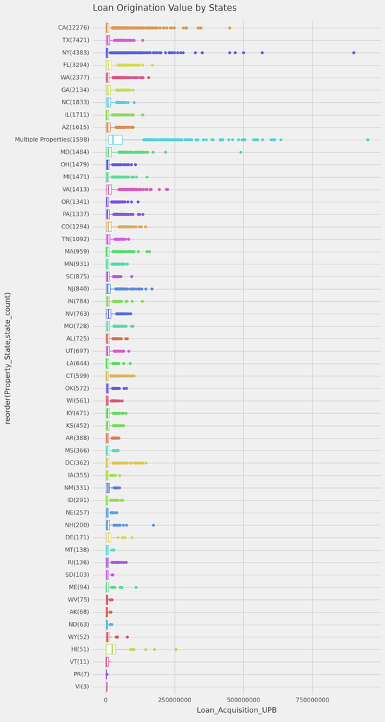

```
<Figure Size: (800 x 1500)>
```

```python
(
ggplot(data =
    mf_df_scan4
    .with_columns(
        pl.col('Loan Acquisition UPB').str.replace_all(r"$|,","").alias('Loan Acquisition UPB')
        )
    .with_columns(pl.col('Loan Acquisition UPB').str.lstrip("$").alias('Loan Acquisition UPB')
                  .cast(pl.Float64)
                  )
    .select('Loan Number','Loan Acquisition UPB','Property City','Property State')
    .unique()

    .with_columns(state_count = pl.count().over('Property State'))
    .with_columns((pl.col('Property State') + "(" + pl.col('state_count').cast(pl.Utf8) + ")").alias('Property State'))

    .rename({"Loan Acquisition UPB":"Loan_Acquisition_UPB",
             "Property State":"Property_State"})
    .collect()
    ,
    mapping = aes(x = 'reorder(Property_State,state_count)',
                  y = "Loan_Acquisition_UPB",
                  color = "Property_State"))
    + geom_boxplot()
    + coord_flip()
    # + geom_jitter()
    + theme_538()
    + theme(legend_position="none",
            figure_size=(8, 15))
    + labs(title = "Loan Origination Value by States")
)
```

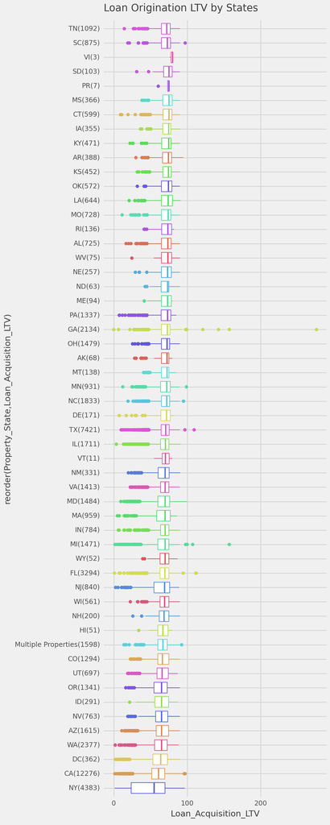

```
<Figure Size: (600 x 1500)>
```

```python
(
ggplot(data =
    mf_df_scan4
    .select('Loan Number','Loan Acquisition LTV','Property City','Property State')
    .unique()

    .with_columns(state_count = pl.count().over('Property State'))
    .with_columns((pl.col('Property State') + "(" + pl.col('state_count').cast(pl.Utf8) + ")").alias('Property State'))

    .rename({"Loan Acquisition LTV":"Loan_Acquisition_LTV",
             "Property State":"Property_State"})
    .collect()
    ,
    mapping = aes(x = 'reorder(Property_State,Loan_Acquisition_LTV)',
                  y = "Loan_Acquisition_LTV",
                  color = "Property_State"))
    + geom_boxplot()
    + coord_flip()
    # + geom_jitter()
    + theme_538()
    + theme(legend_position="none",
            figure_size=(6, 15))
    + labs(title = "Loan Origination LTV by States")
)
```

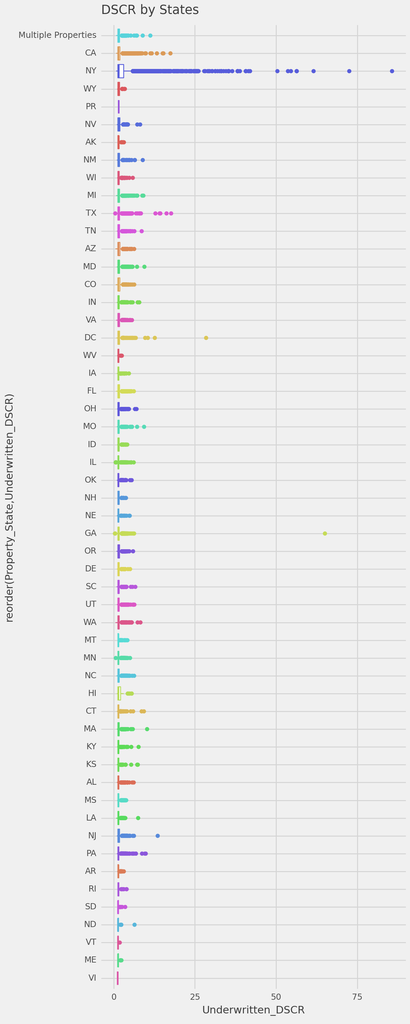

```
<Figure Size: (600 x 1500)>
```

```python
(
ggplot(data =
    mf_df_scan4
    .select('Loan Number','Underwritten DSCR','Property City','Property State')
    .unique()
    .rename({"Underwritten DSCR":"Underwritten_DSCR",
             "Property State":"Property_State"})
    .collect()
    ,
    mapping = aes(x = 'reorder(Property_State,Underwritten_DSCR)',
                  y = "Underwritten_DSCR",
                  color = "Property_State"))
    + geom_boxplot()
    + coord_flip()
    # + geom_jitter()
    + theme_538()
    + theme(legend_position="none",
            figure_size=(6, 15))
    + labs(title = "DSCR by States")
)
```

```python
mf_df_scan4.filter(pl.col('Loan Acquisition LTV') > 100).collect()
```

shape: (549, 62)

| Loan Number i64 | Acquisition Date date | Note Date date | Maturity Date at Acquisition date | Loan Acquisition UPB str | Amortization Type str | Interest Type str | Loan Product Type str | Original UPB str | Amortization Term i64 | Original Interest Rate f64 | Lien Position str | Transaction ID i64 | Issue Date date | Loan Acquisition LTV f64 | Underwritten DSCR f64 | Underwritten DSCR Type str | Original Term i64 | Original I/O Term str | I/O End Date str | Loan Ever 60+ Days Delinquent str | Loss Sharing Type str | Modified Loss Sharing Percentage str | Number of Properties at Acquisition i64 | Property Acquisition Total Unit Count i64 | Specific Property Type str | Year Built i64 | Property City str | Property State str | Property Zip Code i64 | … |
| --- | --- | --- | --- | --- | --- | --- | --- | --- | --- | --- | --- | --- | --- | --- | --- | --- | --- | --- | --- | --- | --- | --- | --- | --- | --- | --- | --- | --- | --- | --- |
| 8000988880 | 2004-08-05 | 2004-07-28 | 2024-04-01 | "$3,210,000.00" | "Amortizing Bal… | "Fixed" | "DUS" | "$3,210,000.00" | 360 | 6.8 | "First" | null | 2012-11-01 | 112.4 | 1.28 | "Lender UW DSCR… | 236 | null | null | "N" | "Standard DUS" | null | 1 | 150 | "Multifamily" | 2004 | "PANAMA CITY" | "FL" | 32405 | … |
| 8000988880 | 2004-08-05 | 2004-07-28 | 2024-04-01 | "$3,210,000.00" | "Amortizing Bal… | "Fixed" | "DUS" | "$3,210,000.00" | 360 | 6.8 | "First" | null | 2012-11-01 | 112.4 | 1.28 | "Lender UW DSCR… | 236 | null | null | "N" | "Standard DUS" | null | 1 | 150 | "Multifamily" | 2004 | "PANAMA CITY" | "FL" | 32405 | … |
| 8000988880 | 2004-08-05 | 2004-07-28 | 2024-04-01 | "$3,210,000.00" | "Amortizing Bal… | "Fixed" | "DUS" | "$3,210,000.00" | 360 | 6.8 | "First" | null | 2012-11-01 | 112.4 | 1.28 | "Lender UW DSCR… | 236 | null | null | "N" | "Standard DUS" | null | 1 | 150 | "Multifamily" | 2004 | "PANAMA CITY" | "FL" | 32405 | … |
| 8000988880 | 2004-08-05 | 2004-07-28 | 2024-04-01 | "$3,210,000.00" | "Amortizing Bal… | "Fixed" | "DUS" | "$3,210,000.00" | 360 | 6.8 | "First" | null | 2012-11-01 | 112.4 | 1.28 | "Lender UW DSCR… | 236 | null | null | "N" | "Standard DUS" | null | 1 | 150 | "Multifamily" | 2004 | "PANAMA CITY" | "FL" | 32405 | … |
| 8000988880 | 2004-08-05 | 2004-07-28 | 2024-04-01 | "$3,210,000.00" | "Amortizing Bal… | "Fixed" | "DUS" | "$3,210,000.00" | 360 | 6.8 | "First" | null | 2012-11-01 | 112.4 | 1.28 | "Lender UW DSCR… | 236 | null | null | "N" | "Standard DUS" | null | 1 | 150 | "Multifamily" | 2004 | "PANAMA CITY" | "FL" | 32405 | … |
| 8000988880 | 2004-08-05 | 2004-07-28 | 2024-04-01 | "$3,210,000.00" | "Amortizing Bal… | "Fixed" | "DUS" | "$3,210,000.00" | 360 | 6.8 | "First" | null | 2012-11-01 | 112.4 | 1.28 | "Lender UW DSCR… | 236 | null | null | "N" | "Standard DUS" | null | 1 | 150 | "Multifamily" | 2004 | "PANAMA CITY" | "FL" | 32405 | … |
| 8000988880 | 2004-08-05 | 2004-07-28 | 2024-04-01 | "$3,210,000.00" | "Amortizing Bal… | "Fixed" | "DUS" | "$3,210,000.00" | 360 | 6.8 | "First" | null | 2012-11-01 | 112.4 | 1.28 | "Lender UW DSCR… | 236 | null | null | "N" | "Standard DUS" | null | 1 | 150 | "Multifamily" | 2004 | "PANAMA CITY" | "FL" | 32405 | … |
| 8000988880 | 2004-08-05 | 2004-07-28 | 2024-04-01 | "$3,210,000.00" | "Amortizing Bal… | "Fixed" | "DUS" | "$3,210,000.00" | 360 | 6.8 | "First" | null | 2012-11-01 | 112.4 | 1.28 | "Lender UW DSCR… | 236 | null | null | "N" | "Standard DUS" | null | 1 | 150 | "Multifamily" | 2004 | "PANAMA CITY" | "FL" | 32405 | … |
| 8000988880 | 2004-08-05 | 2004-07-28 | 2024-04-01 | "$3,210,000.00" | "Amortizing Bal… | "Fixed" | "DUS" | "$3,210,000.00" | 360 | 6.8 | "First" | null | 2012-11-01 | 112.4 | 1.28 | "Lender UW DSCR… | 236 | null | null | "N" | "Standard DUS" | null | 1 | 150 | "Multifamily" | 2004 | "PANAMA CITY" | "FL" | 32405 | … |
| 8000988880 | 2004-08-05 | 2004-07-28 | 2024-04-01 | "$3,210,000.00" | "Amortizing Bal… | "Fixed" | "DUS" | "$3,210,000.00" | 360 | 6.8 | "First" | null | 2012-11-01 | 112.4 | 1.28 | "Lender UW DSCR… | 236 | null | null | "N" | "Standard DUS" | null | 1 | 150 | "Multifamily" | 2004 | "PANAMA CITY" | "FL" | 32405 | … |
| 8000988880 | 2004-08-05 | 2004-07-28 | 2024-04-01 | "$3,210,000.00" | "Amortizing Bal… | "Fixed" | "DUS" | "$3,210,000.00" | 360 | 6.8 | "First" | null | 2012-11-01 | 112.4 | 1.28 | "Lender UW DSCR… | 236 | null | null | "N" | "Standard DUS" | null | 1 | 150 | "Multifamily" | 2004 | "PANAMA CITY" | "FL" | 32405 | … |
| 8000988880 | 2004-08-05 | 2004-07-28 | 2024-04-01 | "$3,210,000.00" | "Amortizing Bal… | "Fixed" | "DUS" | "$3,210,000.00" | 360 | 6.8 | "First" | null | 2012-11-01 | 112.4 | 1.28 | "Lender UW DSCR… | 236 | null | null | "N" | "Standard DUS" | null | 1 | 150 | "Multifamily" | 2004 | "PANAMA CITY" | "FL" | 32405 | … |
| … | … | … | … | … | … | … | … | … | … | … | … | … | … | … | … | … | … | … | … | … | … | … | … | … | … | … | … | … | … | … |
| 8300008128 | 2012-10-26 | 2012-10-01 | 2017-10-01 | "$7,276,787.00" | "Amortizing Bal… | "ARM" | "DUS" | "$7,276,787.00" | 360 | 3.614 | "First" | null | null | 121.3 | 1.43 | "UW Actual DSCR… | 60 | null | null | "N" | "Standard DUS" | null | 1 | 188 | "Multifamily" | 2000 | "COVINGTON" | "GA" | 30016 | … |
| 8300008128 | 2012-10-26 | 2012-10-01 | 2017-10-01 | "$7,276,787.00" | "Amortizing Bal… | "ARM" | "DUS" | "$7,276,787.00" | 360 | 3.614 | "First" | null | null | 121.3 | 1.43 | "UW Actual DSCR… | 60 | null | null | "N" | "Standard DUS" | null | 1 | 188 | "Multifamily" | 2000 | "COVINGTON" | "GA" | 30016 | … |
| 8300008128 | 2012-10-26 | 2012-10-01 | 2017-10-01 | "$7,276,787.00" | "Amortizing Bal… | "ARM" | "DUS" | "$7,276,787.00" | 360 | 3.614 | "First" | null | null | 121.3 | 1.43 | "UW Actual DSCR… | 60 | null | null | "N" | "Standard DUS" | null | 1 | 188 | "Multifamily" | 2000 | "COVINGTON" | "GA" | 30016 | … |
| 8300008128 | 2012-10-26 | 2012-10-01 | 2017-10-01 | "$7,276,787.00" | "Amortizing Bal… | "ARM" | "DUS" | "$7,276,787.00" | 360 | 3.614 | "First" | null | null | 121.3 | 1.43 | "UW Actual DSCR… | 60 | null | null | "N" | "Standard DUS" | null | 1 | 188 | "Multifamily" | 2000 | "COVINGTON" | "GA" | 30016 | … |
| 8300008128 | 2012-10-26 | 2012-10-01 | 2017-10-01 | "$7,276,787.00" | "Amortizing Bal… | "ARM" | "DUS" | "$7,276,787.00" | 360 | 3.614 | "First" | null | null | 121.3 | 1.43 | "UW Actual DSCR… | 60 | null | null | "N" | "Standard DUS" | null | 1 | 188 | "Multifamily" | 2000 | "COVINGTON" | "GA" | 30016 | … |
| 8300008128 | 2012-10-26 | 2012-10-01 | 2017-10-01 | "$7,276,787.00" | "Amortizing Bal… | "ARM" | "DUS" | "$7,276,787.00" | 360 | 3.614 | "First" | null | null | 121.3 | 1.43 | "UW Actual DSCR… | 60 | null | null | "N" | "Standard DUS" | null | 1 | 188 | "Multifamily" | 2000 | "COVINGTON" | "GA" | 30016 | … |
| 8300008128 | 2012-10-26 | 2012-10-01 | 2017-10-01 | "$7,276,787.00" | "Amortizing Bal… | "ARM" | "DUS" | "$7,276,787.00" | 360 | 3.614 | "First" | null | null | 121.3 | 1.43 | "UW Actual DSCR… | 60 | null | null | "N" | "Standard DUS" | null | 1 | 188 | "Multifamily" | 2000 | "COVINGTON" | "GA" | 30016 | … |
| 8300008128 | 2012-10-26 | 2012-10-01 | 2017-10-01 | "$7,276,787.00" | "Amortizing Bal… | "ARM" | "DUS" | "$7,276,787.00" | 360 | 3.614 | "First" | null | null | 121.3 | 1.43 | "UW Actual DSCR… | 60 | null | null | "N" | "Standard DUS" | null | 1 | 188 | "Multifamily" | 2000 | "COVINGTON" | "GA" | 30016 | … |
| 8300008128 | 2012-10-26 | 2012-10-01 | 2017-10-01 | "$7,276,787.00" | "Amortizing Bal… | "ARM" | "DUS" | "$7,276,787.00" | 360 | 3.614 | "First" | null | null | 121.3 | 1.43 | "UW Actual DSCR… | 60 | null | null | "N" | "Standard DUS" | null | 1 | 188 | "Multifamily" | 2000 | "COVINGTON" | "GA" | 30016 | … |
| 8300008128 | 2012-10-26 | 2012-10-01 | 2017-10-01 | "$7,276,787.00" | "Amortizing Bal… | "ARM" | "DUS" | "$7,276,787.00" | 360 | 3.614 | "First" | null | null | 121.3 | 1.43 | "UW Actual DSCR… | 60 | null | null | "N" | "Standard DUS" | null | 1 | 188 | "Multifamily" | 2000 | "COVINGTON" | "GA" | 30016 | … |
| 8300008128 | 2012-10-26 | 2012-10-01 | 2017-10-01 | "$7,276,787.00" | "Amortizing Bal… | "ARM" | "DUS" | "$7,276,787.00" | 360 | 3.614 | "First" | null | null | 121.3 | 1.43 | "UW Actual DSCR… | 60 | null | null | "N" | "Standard DUS" | null | 1 | 188 | "Multifamily" | 2000 | "COVINGTON" | "GA" | 30016 | … |
| 8300008128 | 2012-10-26 | 2012-10-01 | 2017-10-01 | "$7,276,787.00" | "Amortizing Bal… | "ARM" | "DUS" | "$7,276,787.00" | 360 | 3.614 | "First" | null | null | 121.3 | 1.43 | "UW Actual DSCR… | 60 | null | null | "N" | "Standard DUS" | null | 1 | 188 | "Multifamily" | 2000 | "COVINGTON" | "GA" | 30016 | … |

### mf 2018

```python
mf_df_2018 = mf_df_scan4.filter(pl.col('Acquisition Date') >= dt.date(2018,1,1))

mf_df_2018.head().collect()
```

shape: (5, 62)

| Loan Number i64 | Acquisition Date date | Note Date date | Maturity Date at Acquisition date | Loan Acquisition UPB str | Amortization Type str | Interest Type str | Loan Product Type str | Original UPB str | Amortization Term i64 | Original Interest Rate f64 | Lien Position str | Transaction ID i64 | Issue Date date | Loan Acquisition LTV f64 | Underwritten DSCR f64 | Underwritten DSCR Type str | Original Term i64 | Original I/O Term str | I/O End Date str | Loan Ever 60+ Days Delinquent str | Loss Sharing Type str | Modified Loss Sharing Percentage str | Number of Properties at Acquisition i64 | Property Acquisition Total Unit Count i64 | Specific Property Type str | Year Built i64 | Property City str | Property State str | Property Zip Code i64 | … |
| --- | --- | --- | --- | --- | --- | --- | --- | --- | --- | --- | --- | --- | --- | --- | --- | --- | --- | --- | --- | --- | --- | --- | --- | --- | --- | --- | --- | --- | --- | --- |
| 1717473792 | 2018-01-12 | 2017-11-21 | 2029-12-01 | "$923,926.94" | "Amortizing Bal… | "Fixed" | "DUS" | "$925,000.00" | 360 | 4.62 | "First" | null | 2018-01-01 | 64.6 | 1.43 | "UW DSCR NCF" | 144 | null | null | "N" | "Standard DUS" | null | 1 | 25 | "Multifamily" | 1980 | "CLEARWATER" | "MN" | 55320 | … |
| 1717473792 | 2018-01-12 | 2017-11-21 | 2029-12-01 | "$923,926.94" | "Amortizing Bal… | "Fixed" | "DUS" | "$925,000.00" | 360 | 4.62 | "First" | null | 2018-01-01 | 64.6 | 1.43 | "UW DSCR NCF" | 144 | null | null | "N" | "Standard DUS" | null | 1 | 25 | "Multifamily" | 1980 | "CLEARWATER" | "MN" | 55320 | … |
| 1717473792 | 2018-01-12 | 2017-11-21 | 2029-12-01 | "$923,926.94" | "Amortizing Bal… | "Fixed" | "DUS" | "$925,000.00" | 360 | 4.62 | "First" | null | 2018-01-01 | 64.6 | 1.43 | "UW DSCR NCF" | 144 | null | null | "N" | "Standard DUS" | null | 1 | 25 | "Multifamily" | 1980 | "CLEARWATER" | "MN" | 55320 | … |
| 1717473792 | 2018-01-12 | 2017-11-21 | 2029-12-01 | "$923,926.94" | "Amortizing Bal… | "Fixed" | "DUS" | "$925,000.00" | 360 | 4.62 | "First" | null | 2018-01-01 | 64.6 | 1.43 | "UW DSCR NCF" | 144 | null | null | "N" | "Standard DUS" | null | 1 | 25 | "Multifamily" | 1980 | "CLEARWATER" | "MN" | 55320 | … |
| 1717473792 | 2018-01-12 | 2017-11-21 | 2029-12-01 | "$923,926.94" | "Amortizing Bal… | "Fixed" | "DUS" | "$925,000.00" | 360 | 4.62 | "First" | null | 2018-01-01 | 64.6 | 1.43 | "UW DSCR NCF" | 144 | null | null | "N" | "Standard DUS" | null | 1 | 25 | "Multifamily" | 1980 | "CLEARWATER" | "MN" | 55320 | … |

```python
mf_df_2018.select(pl.count()).collect()
```

shape: (1, 1)

| count u32 |
| --- |
| 599666 |

```python
(mf_df_2018
 .groupby('Loan Number')
 .count()
 .sort('count', descending=True)
 .head()
 .collect()
 )
```

shape: (5, 2)

| Loan Number i64 | count u32 |
| --- | --- |
| 1717474212 | 60 |
| 1717474176 | 60 |
| 1717474270 | 60 |
| 1717474268 | 60 |
| 1717474153 | 60 |

```python
(mf_df_2018
    .groupby('Loan Number')
    .count()
    .sort('count', descending=True)
    .head(1)
    .select(pl.col('Loan Number'))
    .collect()
    .to_series()[0]
)
```

```
1717474014
```

```python
(mf_df_2018
 .filter(pl.col('Loan Number')
         .is_in(
                mf_df_2018
                .groupby('Loan Number')
                .count()
                .sort('count', descending=True)
                .head(1)
                .select(pl.col('Loan Number'))
                .collect()
                .to_series()[0]
                )
        ).collect()
        .sort('Reporting Period Date')
 )
```

shape: (60, 62)

| Loan Number i64 | Acquisition Date date | Note Date date | Maturity Date at Acquisition date | Loan Acquisition UPB str | Amortization Type str | Interest Type str | Loan Product Type str | Original UPB str | Amortization Term i64 | Original Interest Rate f64 | Lien Position str | Transaction ID i64 | Issue Date date | Loan Acquisition LTV f64 | Underwritten DSCR f64 | Underwritten DSCR Type str | Original Term i64 | Original I/O Term str | I/O End Date str | Loan Ever 60+ Days Delinquent str | Loss Sharing Type str | Modified Loss Sharing Percentage str | Number of Properties at Acquisition i64 | Property Acquisition Total Unit Count i64 | Specific Property Type str | Year Built i64 | Property City str | Property State str | Property Zip Code i64 | … |
| --- | --- | --- | --- | --- | --- | --- | --- | --- | --- | --- | --- | --- | --- | --- | --- | --- | --- | --- | --- | --- | --- | --- | --- | --- | --- | --- | --- | --- | --- | --- |
| 1717474101 | 2018-01-19 | 2017-12-14 | 2028-01-01 | "$12,750,000.00… | "Interest Only/… | "Fixed" | "DUS" | "$12,750,000.00… | 360 | 3.79 | "First" | null | 2018-01-01 | 51.6 | 1.75 | "UW DSCR NCF" | 120 | "60" | "2023-01-01" | "N" | "Pari Passu" | null | 1 | 168 | "Multifamily" | 2002 | "PHOENIX" | "AZ" | 85053 | … |
| 1717474101 | 2018-01-19 | 2017-12-14 | 2028-01-01 | "$12,750,000.00… | "Interest Only/… | "Fixed" | "DUS" | "$12,750,000.00… | 360 | 3.79 | "First" | null | 2018-01-01 | 51.6 | 1.75 | "UW DSCR NCF" | 120 | "60" | "2023-01-01" | "N" | "Pari Passu" | null | 1 | 168 | "Multifamily" | 2002 | "PHOENIX" | "AZ" | 85053 | … |
| 1717474101 | 2018-01-19 | 2017-12-14 | 2028-01-01 | "$12,750,000.00… | "Interest Only/… | "Fixed" | "DUS" | "$12,750,000.00… | 360 | 3.79 | "First" | null | 2018-01-01 | 51.6 | 1.75 | "UW DSCR NCF" | 120 | "60" | "2023-01-01" | "N" | "Pari Passu" | null | 1 | 168 | "Multifamily" | 2002 | "PHOENIX" | "AZ" | 85053 | … |
| 1717474101 | 2018-01-19 | 2017-12-14 | 2028-01-01 | "$12,750,000.00… | "Interest Only/… | "Fixed" | "DUS" | "$12,750,000.00… | 360 | 3.79 | "First" | null | 2018-01-01 | 51.6 | 1.75 | "UW DSCR NCF" | 120 | "60" | "2023-01-01" | "N" | "Pari Passu" | null | 1 | 168 | "Multifamily" | 2002 | "PHOENIX" | "AZ" | 85053 | … |
| 1717474101 | 2018-01-19 | 2017-12-14 | 2028-01-01 | "$12,750,000.00… | "Interest Only/… | "Fixed" | "DUS" | "$12,750,000.00… | 360 | 3.79 | "First" | null | 2018-01-01 | 51.6 | 1.75 | "UW DSCR NCF" | 120 | "60" | "2023-01-01" | "N" | "Pari Passu" | null | 1 | 168 | "Multifamily" | 2002 | "PHOENIX" | "AZ" | 85053 | … |
| 1717474101 | 2018-01-19 | 2017-12-14 | 2028-01-01 | "$12,750,000.00… | "Interest Only/… | "Fixed" | "DUS" | "$12,750,000.00… | 360 | 3.79 | "First" | null | 2018-01-01 | 51.6 | 1.75 | "UW DSCR NCF" | 120 | "60" | "2023-01-01" | "N" | "Pari Passu" | null | 1 | 168 | "Multifamily" | 2002 | "PHOENIX" | "AZ" | 85053 | … |
| 1717474101 | 2018-01-19 | 2017-12-14 | 2028-01-01 | "$12,750,000.00… | "Interest Only/… | "Fixed" | "DUS" | "$12,750,000.00… | 360 | 3.79 | "First" | null | 2018-01-01 | 51.6 | 1.75 | "UW DSCR NCF" | 120 | "60" | "2023-01-01" | "N" | "Pari Passu" | null | 1 | 168 | "Multifamily" | 2002 | "PHOENIX" | "AZ" | 85053 | … |
| 1717474101 | 2018-01-19 | 2017-12-14 | 2028-01-01 | "$12,750,000.00… | "Interest Only/… | "Fixed" | "DUS" | "$12,750,000.00… | 360 | 3.79 | "First" | null | 2018-01-01 | 51.6 | 1.75 | "UW DSCR NCF" | 120 | "60" | "2023-01-01" | "N" | "Pari Passu" | null | 1 | 168 | "Multifamily" | 2002 | "PHOENIX" | "AZ" | 85053 | … |
| 1717474101 | 2018-01-19 | 2017-12-14 | 2028-01-01 | "$12,750,000.00… | "Interest Only/… | "Fixed" | "DUS" | "$12,750,000.00… | 360 | 3.79 | "First" | null | 2018-01-01 | 51.6 | 1.75 | "UW DSCR NCF" | 120 | "60" | "2023-01-01" | "N" | "Pari Passu" | null | 1 | 168 | "Multifamily" | 2002 | "PHOENIX" | "AZ" | 85053 | … |
| 1717474101 | 2018-01-19 | 2017-12-14 | 2028-01-01 | "$12,750,000.00… | "Interest Only/… | "Fixed" | "DUS" | "$12,750,000.00… | 360 | 3.79 | "First" | null | 2018-01-01 | 51.6 | 1.75 | "UW DSCR NCF" | 120 | "60" | "2023-01-01" | "N" | "Pari Passu" | null | 1 | 168 | "Multifamily" | 2002 | "PHOENIX" | "AZ" | 85053 | … |
| 1717474101 | 2018-01-19 | 2017-12-14 | 2028-01-01 | "$12,750,000.00… | "Interest Only/… | "Fixed" | "DUS" | "$12,750,000.00… | 360 | 3.79 | "First" | null | 2018-01-01 | 51.6 | 1.75 | "UW DSCR NCF" | 120 | "60" | "2023-01-01" | "N" | "Pari Passu" | null | 1 | 168 | "Multifamily" | 2002 | "PHOENIX" | "AZ" | 85053 | … |
| 1717474101 | 2018-01-19 | 2017-12-14 | 2028-01-01 | "$12,750,000.00… | "Interest Only/… | "Fixed" | "DUS" | "$12,750,000.00… | 360 | 3.79 | "First" | null | 2018-01-01 | 51.6 | 1.75 | "UW DSCR NCF" | 120 | "60" | "2023-01-01" | "N" | "Pari Passu" | null | 1 | 168 | "Multifamily" | 2002 | "PHOENIX" | "AZ" | 85053 | … |
| … | … | … | … | … | … | … | … | … | … | … | … | … | … | … | … | … | … | … | … | … | … | … | … | … | … | … | … | … | … | … |
| 1717474101 | 2018-01-19 | 2017-12-14 | 2028-01-01 | "$12,750,000.00… | "Interest Only/… | "Fixed" | "DUS" | "$12,750,000.00… | 360 | 3.79 | "First" | null | 2018-01-01 | 51.6 | 1.75 | "UW DSCR NCF" | 120 | "60" | "2023-01-01" | "N" | "Pari Passu" | null | 1 | 168 | "Multifamily" | 2002 | "PHOENIX" | "AZ" | 85053 | … |
| 1717474101 | 2018-01-19 | 2017-12-14 | 2028-01-01 | "$12,750,000.00… | "Interest Only/… | "Fixed" | "DUS" | "$12,750,000.00… | 360 | 3.79 | "First" | null | 2018-01-01 | 51.6 | 1.75 | "UW DSCR NCF" | 120 | "60" | "2023-01-01" | "N" | "Pari Passu" | null | 1 | 168 | "Multifamily" | 2002 | "PHOENIX" | "AZ" | 85053 | … |
| 1717474101 | 2018-01-19 | 2017-12-14 | 2028-01-01 | "$12,750,000.00… | "Interest Only/… | "Fixed" | "DUS" | "$12,750,000.00… | 360 | 3.79 | "First" | null | 2018-01-01 | 51.6 | 1.75 | "UW DSCR NCF" | 120 | "60" | "2023-01-01" | "N" | "Pari Passu" | null | 1 | 168 | "Multifamily" | 2002 | "PHOENIX" | "AZ" | 85053 | … |
| 1717474101 | 2018-01-19 | 2017-12-14 | 2028-01-01 | "$12,750,000.00… | "Interest Only/… | "Fixed" | "DUS" | "$12,750,000.00… | 360 | 3.79 | "First" | null | 2018-01-01 | 51.6 | 1.75 | "UW DSCR NCF" | 120 | "60" | "2023-01-01" | "N" | "Pari Passu" | null | 1 | 168 | "Multifamily" | 2002 | "PHOENIX" | "AZ" | 85053 | … |
| 1717474101 | 2018-01-19 | 2017-12-14 | 2028-01-01 | "$12,750,000.00… | "Interest Only/… | "Fixed" | "DUS" | "$12,750,000.00… | 360 | 3.79 | "First" | null | 2018-01-01 | 51.6 | 1.75 | "UW DSCR NCF" | 120 | "60" | "2023-01-01" | "N" | "Pari Passu" | null | 1 | 168 | "Multifamily" | 2002 | "PHOENIX" | "AZ" | 85053 | … |
| 1717474101 | 2018-01-19 | 2017-12-14 | 2028-01-01 | "$12,750,000.00… | "Interest Only/… | "Fixed" | "DUS" | "$12,750,000.00… | 360 | 3.79 | "First" | null | 2018-01-01 | 51.6 | 1.75 | "UW DSCR NCF" | 120 | "60" | "2023-01-01" | "N" | "Pari Passu" | null | 1 | 168 | "Multifamily" | 2002 | "PHOENIX" | "AZ" | 85053 | … |
| 1717474101 | 2018-01-19 | 2017-12-14 | 2028-01-01 | "$12,750,000.00… | "Interest Only/… | "Fixed" | "DUS" | "$12,750,000.00… | 360 | 3.79 | "First" | null | 2018-01-01 | 51.6 | 1.75 | "UW DSCR NCF" | 120 | "60" | "2023-01-01" | "N" | "Pari Passu" | null | 1 | 168 | "Multifamily" | 2002 | "PHOENIX" | "AZ" | 85053 | … |
| 1717474101 | 2018-01-19 | 2017-12-14 | 2028-01-01 | "$12,750,000.00… | "Interest Only/… | "Fixed" | "DUS" | "$12,750,000.00… | 360 | 3.79 | "First" | null | 2018-01-01 | 51.6 | 1.75 | "UW DSCR NCF" | 120 | "60" | "2023-01-01" | "N" | "Pari Passu" | null | 1 | 168 | "Multifamily" | 2002 | "PHOENIX" | "AZ" | 85053 | … |
| 1717474101 | 2018-01-19 | 2017-12-14 | 2028-01-01 | "$12,750,000.00… | "Interest Only/… | "Fixed" | "DUS" | "$12,750,000.00… | 360 | 3.79 | "First" | null | 2018-01-01 | 51.6 | 1.75 | "UW DSCR NCF" | 120 | "60" | "2023-01-01" | "N" | "Pari Passu" | null | 1 | 168 | "Multifamily" | 2002 | "PHOENIX" | "AZ" | 85053 | … |
| 1717474101 | 2018-01-19 | 2017-12-14 | 2028-01-01 | "$12,750,000.00… | "Interest Only/… | "Fixed" | "DUS" | "$12,750,000.00… | 360 | 3.79 | "First" | null | 2018-01-01 | 51.6 | 1.75 | "UW DSCR NCF" | 120 | "60" | "2023-01-01" | "N" | "Pari Passu" | null | 1 | 168 | "Multifamily" | 2002 | "PHOENIX" | "AZ" | 85053 | … |
| 1717474101 | 2018-01-19 | 2017-12-14 | 2028-01-01 | "$12,750,000.00… | "Interest Only/… | "Fixed" | "DUS" | "$12,750,000.00… | 360 | 3.79 | "First" | null | 2018-01-01 | 51.6 | 1.75 | "UW DSCR NCF" | 120 | "60" | "2023-01-01" | "N" | "Pari Passu" | null | 1 | 168 | "Multifamily" | 2002 | "PHOENIX" | "AZ" | 85053 | … |
| 1717474101 | 2018-01-19 | 2017-12-14 | 2028-01-01 | "$12,750,000.00… | "Interest Only/… | "Fixed" | "DUS" | "$12,750,000.00… | 360 | 3.79 | "First" | null | 2018-01-01 | 51.6 | 1.75 | "UW DSCR NCF" | 120 | "60" | "2023-01-01" | "N" | "Pari Passu" | null | 1 | 168 | "Multifamily" | 2002 | "PHOENIX" | "AZ" | 85053 | … |

```python
(
    mf_df_2018.groupby('Loan Number')
    .agg(Payment_Status_counts = pl.n_unique('Loan Payment Status'))
    .sort('Payment_Status_counts', descending=True)
    .head()
    .collect()
)
```

shape: (5, 2)

| Loan Number i64 | Payment_Status_counts u32 |
| --- | --- |
| 1717474100 | 4 |
| 1717477314 | 4 |
| 1717480511 | 4 |
| 1717474624 | 4 |
| 1717481376 | 4 |

```python
(
    mf_df_2018
    .groupby('Loan Number', maintain_order=True)
    .agg(Payment_Status_counts = pl.n_unique('Loan Payment Status'),
         Payment_Status_list = pl.col('Loan Payment Status').unique().sort()
                                    )
    .sort('Payment_Status_counts', descending=True)
    .collect()
)
```

shape: (20_632, 3)

| Loan Number i64 | Payment_Status_counts u32 | Payment_Status_list list[str] |
| --- | --- | --- |
| 1717473898 | 4 | ["30-59 Days Delinquent", "60-89 Days Delinquent", … "Current"] |
| 1717474039 | 4 | ["30-59 Days Delinquent", "60-89 Days Delinquent", … "Current"] |
| 1717474100 | 4 | ["30-59 Days Delinquent", "60-89 Days Delinquent", … "Current"] |
| 1717474216 | 4 | ["30-59 Days Delinquent", "60-89 Days Delinquent", … "Current"] |
| 1717474217 | 4 | ["30-59 Days Delinquent", "60-89 Days Delinquent", … "Current"] |
| 1717474220 | 4 | ["30-59 Days Delinquent", "60-89 Days Delinquent", … "Current"] |
| 1717474467 | 4 | ["30-59 Days Delinquent", "60-89 Days Delinquent", … "Current"] |
| 1717474497 | 4 | ["30-59 Days Delinquent", "60-89 Days Delinquent", … "Current"] |
| 1717474516 | 4 | ["30-59 Days Delinquent", "60-89 Days Delinquent", … "Current"] |
| 1717474595 | 4 | ["30-59 Days Delinquent", "60-89 Days Delinquent", … "Current"] |
| 1717474613 | 4 | ["30-59 Days Delinquent", "60-89 Days Delinquent", … "Current"] |
| 1717474624 | 4 | ["30-59 Days Delinquent", "60-89 Days Delinquent", … "Current"] |
| … | … | … |
| 1740002336 | 1 | ["Current"] |
| 1740002337 | 1 | ["Current"] |
| 1740002339 | 1 | ["Current"] |
| 1740002341 | 1 | ["Current"] |
| 1740002346 | 1 | ["Current"] |
| 8300008163 | 1 | ["Current"] |
| 8300008164 | 1 | ["Current"] |
| 8300008165 | 1 | ["Current"] |
| 8300008170 | 1 | ["Current"] |
| 8300008173 | 1 | ["Current"] |
| 8300008174 | 1 | ["Current"] |
| 8300008176 | 1 | ["Current"] |

```python
# Number of Loans with 4,3,2,1 Payment Status since 2018
(
    mf_df_2018.groupby('Loan Number')
    .agg(Payment_Status_counts = pl.n_unique('Loan Payment Status'))
    .sort('Payment_Status_counts', descending=True)
    .groupby('Payment_Status_counts').count()
    .collect()
)
```

shape: (4, 2)

| Payment_Status_counts u32 | count u32 |
| --- | --- |
| 4 | 124 |
| 3 | 11 |
| 2 | 84 |
| 1 | 20413 |

```python
# Percentage Number of Loans with 4,3,2,1 Payment Status since 2018
(
    mf_df_2018.groupby('Loan Number')
    .agg(Payment_Status_counts = pl.n_unique('Loan Payment Status'))
    .sort('Payment_Status_counts', descending=True)
    .groupby('Payment_Status_counts').count()
    .with_columns(Payment_Status_counts_perc = pl.col('count') / pl.sum('count') * 100)
    .collect()
)
```

shape: (4, 3)

| Payment_Status_counts u32 | count u32 | Payment_Status_counts_perc f64 |
| --- | --- | --- |
| 4 | 124 | 0.601008 |
| 3 | 11 | 0.053315 |
| 2 | 84 | 0.407135 |
| 1 | 20413 | 98.938542 |

```python
(
    mf_df_2018.groupby('Loan Number','Loan Payment Status')
    .count()
    .sort(['Loan Number','Loan Payment Status'])
    # .agg(count = pl.count().over('Loan Payment Status'))
    # .sort('count',descending=True)
    .head(12)
    .collect()
)
```

shape: (12, 3)

| Loan Number i64 | Loan Payment Status str | count u32 |
| --- | --- | --- |
| 1717473792 | "Current" | 52 |
| 1717473838 | "Current" | 38 |
| 1717473863 | "Current" | 60 |
| 1717473868 | "Current" | 60 |
| 1717473869 | "Current" | 55 |
| 1717473870 | "Current" | 55 |
| 1717473871 | "Current" | 60 |
| 1717473873 | "Current" | 38 |
| 1717473874 | "Current" | 60 |
| 1717473898 | "30-59 Days Del… | 1 |
| 1717473898 | "60-89 Days Del… | 1 |
| 1717473898 | "90+ Days Delin… | 11 |

```python
(
    mf_df_2018
    .filter(pl.col('Loan Number').is_in(1717474100))
    .sort('Reporting Period Date')
    .collect()
)
```

shape: (34, 62)

| Loan Number i64 | Acquisition Date date | Note Date date | Maturity Date at Acquisition date | Loan Acquisition UPB str | Amortization Type str | Interest Type str | Loan Product Type str | Original UPB str | Amortization Term i64 | Original Interest Rate f64 | Lien Position str | Transaction ID i64 | Issue Date date | Loan Acquisition LTV f64 | Underwritten DSCR f64 | Underwritten DSCR Type str | Original Term i64 | Original I/O Term str | I/O End Date str | Loan Ever 60+ Days Delinquent str | Loss Sharing Type str | Modified Loss Sharing Percentage str | Number of Properties at Acquisition i64 | Property Acquisition Total Unit Count i64 | Specific Property Type str | Year Built i64 | Property City str | Property State str | Property Zip Code i64 | … |
| --- | --- | --- | --- | --- | --- | --- | --- | --- | --- | --- | --- | --- | --- | --- | --- | --- | --- | --- | --- | --- | --- | --- | --- | --- | --- | --- | --- | --- | --- | --- |
| 1717474100 | 2018-01-08 | 2017-12-06 | 2030-01-01 | "$1,100,000.00" | "Interest Only/… | "Fixed" | "DUS" | "$1,100,000.00" | 360 | 4.82 | "First" | null | 2018-01-01 | 78.9 | 1.64 | "UW DSCR NCF" | 144 | "36" | "2021-01-01" | "Y" | "Pari Passu" | null | 1 | 32 | "Multifamily" | 1970 | "SPRINGFIELD" | "MA" | 1107 | … |
| 1717474100 | 2018-01-08 | 2017-12-06 | 2030-01-01 | "$1,100,000.00" | "Interest Only/… | "Fixed" | "DUS" | "$1,100,000.00" | 360 | 4.82 | "First" | null | 2018-01-01 | 78.9 | 1.64 | "UW DSCR NCF" | 144 | "36" | "2021-01-01" | "Y" | "Pari Passu" | null | 1 | 32 | "Multifamily" | 1970 | "SPRINGFIELD" | "MA" | 1107 | … |
| 1717474100 | 2018-01-08 | 2017-12-06 | 2030-01-01 | "$1,100,000.00" | "Interest Only/… | "Fixed" | "DUS" | "$1,100,000.00" | 360 | 4.82 | "First" | null | 2018-01-01 | 78.9 | 1.64 | "UW DSCR NCF" | 144 | "36" | "2021-01-01" | "Y" | "Pari Passu" | null | 1 | 32 | "Multifamily" | 1970 | "SPRINGFIELD" | "MA" | 1107 | … |
| 1717474100 | 2018-01-08 | 2017-12-06 | 2030-01-01 | "$1,100,000.00" | "Interest Only/… | "Fixed" | "DUS" | "$1,100,000.00" | 360 | 4.82 | "First" | null | 2018-01-01 | 78.9 | 1.64 | "UW DSCR NCF" | 144 | "36" | "2021-01-01" | "Y" | "Pari Passu" | null | 1 | 32 | "Multifamily" | 1970 | "SPRINGFIELD" | "MA" | 1107 | … |
| 1717474100 | 2018-01-08 | 2017-12-06 | 2030-01-01 | "$1,100,000.00" | "Interest Only/… | "Fixed" | "DUS" | "$1,100,000.00" | 360 | 4.82 | "First" | null | 2018-01-01 | 78.9 | 1.64 | "UW DSCR NCF" | 144 | "36" | "2021-01-01" | "Y" | "Pari Passu" | null | 1 | 32 | "Multifamily" | 1970 | "SPRINGFIELD" | "MA" | 1107 | … |
| 1717474100 | 2018-01-08 | 2017-12-06 | 2030-01-01 | "$1,100,000.00" | "Interest Only/… | "Fixed" | "DUS" | "$1,100,000.00" | 360 | 4.82 | "First" | null | 2018-01-01 | 78.9 | 1.64 | "UW DSCR NCF" | 144 | "36" | "2021-01-01" | "Y" | "Pari Passu" | null | 1 | 32 | "Multifamily" | 1970 | "SPRINGFIELD" | "MA" | 1107 | … |
| 1717474100 | 2018-01-08 | 2017-12-06 | 2030-01-01 | "$1,100,000.00" | "Interest Only/… | "Fixed" | "DUS" | "$1,100,000.00" | 360 | 4.82 | "First" | null | 2018-01-01 | 78.9 | 1.64 | "UW DSCR NCF" | 144 | "36" | "2021-01-01" | "Y" | "Pari Passu" | null | 1 | 32 | "Multifamily" | 1970 | "SPRINGFIELD" | "MA" | 1107 | … |
| 1717474100 | 2018-01-08 | 2017-12-06 | 2030-01-01 | "$1,100,000.00" | "Interest Only/… | "Fixed" | "DUS" | "$1,100,000.00" | 360 | 4.82 | "First" | null | 2018-01-01 | 78.9 | 1.64 | "UW DSCR NCF" | 144 | "36" | "2021-01-01" | "Y" | "Pari Passu" | null | 1 | 32 | "Multifamily" | 1970 | "SPRINGFIELD" | "MA" | 1107 | … |
| 1717474100 | 2018-01-08 | 2017-12-06 | 2030-01-01 | "$1,100,000.00" | "Interest Only/… | "Fixed" | "DUS" | "$1,100,000.00" | 360 | 4.82 | "First" | null | 2018-01-01 | 78.9 | 1.64 | "UW DSCR NCF" | 144 | "36" | "2021-01-01" | "Y" | "Pari Passu" | null | 1 | 32 | "Multifamily" | 1970 | "SPRINGFIELD" | "MA" | 1107 | … |
| 1717474100 | 2018-01-08 | 2017-12-06 | 2030-01-01 | "$1,100,000.00" | "Interest Only/… | "Fixed" | "DUS" | "$1,100,000.00" | 360 | 4.82 | "First" | null | 2018-01-01 | 78.9 | 1.64 | "UW DSCR NCF" | 144 | "36" | "2021-01-01" | "Y" | "Pari Passu" | null | 1 | 32 | "Multifamily" | 1970 | "SPRINGFIELD" | "MA" | 1107 | … |
| 1717474100 | 2018-01-08 | 2017-12-06 | 2030-01-01 | "$1,100,000.00" | "Interest Only/… | "Fixed" | "DUS" | "$1,100,000.00" | 360 | 4.82 | "First" | null | 2018-01-01 | 78.9 | 1.64 | "UW DSCR NCF" | 144 | "36" | "2021-01-01" | "Y" | "Pari Passu" | null | 1 | 32 | "Multifamily" | 1970 | "SPRINGFIELD" | "MA" | 1107 | … |
| 1717474100 | 2018-01-08 | 2017-12-06 | 2030-01-01 | "$1,100,000.00" | "Interest Only/… | "Fixed" | "DUS" | "$1,100,000.00" | 360 | 4.82 | "First" | null | 2018-01-01 | 78.9 | 1.64 | "UW DSCR NCF" | 144 | "36" | "2021-01-01" | "Y" | "Pari Passu" | null | 1 | 32 | "Multifamily" | 1970 | "SPRINGFIELD" | "MA" | 1107 | … |
| … | … | … | … | … | … | … | … | … | … | … | … | … | … | … | … | … | … | … | … | … | … | … | … | … | … | … | … | … | … | … |
| 1717474100 | 2018-01-08 | 2017-12-06 | 2030-01-01 | "$1,100,000.00" | "Interest Only/… | "Fixed" | "DUS" | "$1,100,000.00" | 360 | 4.82 | "First" | null | 2018-01-01 | 78.9 | 1.64 | "UW DSCR NCF" | 144 | "36" | "2021-01-01" | "Y" | "Pari Passu" | null | 1 | 32 | "Multifamily" | 1970 | "SPRINGFIELD" | "MA" | 1107 | … |
| 1717474100 | 2018-01-08 | 2017-12-06 | 2030-01-01 | "$1,100,000.00" | "Interest Only/… | "Fixed" | "DUS" | "$1,100,000.00" | 360 | 4.82 | "First" | null | 2018-01-01 | 78.9 | 1.64 | "UW DSCR NCF" | 144 | "36" | "2021-01-01" | "Y" | "Pari Passu" | null | 1 | 32 | "Multifamily" | 1970 | "SPRINGFIELD" | "MA" | 1107 | … |
| 1717474100 | 2018-01-08 | 2017-12-06 | 2030-01-01 | "$1,100,000.00" | "Interest Only/… | "Fixed" | "DUS" | "$1,100,000.00" | 360 | 4.82 | "First" | null | 2018-01-01 | 78.9 | 1.64 | "UW DSCR NCF" | 144 | "36" | "2021-01-01" | "Y" | "Pari Passu" | null | 1 | 32 | "Multifamily" | 1970 | "SPRINGFIELD" | "MA" | 1107 | … |
| 1717474100 | 2018-01-08 | 2017-12-06 | 2030-01-01 | "$1,100,000.00" | "Interest Only/… | "Fixed" | "DUS" | "$1,100,000.00" | 360 | 4.82 | "First" | null | 2018-01-01 | 78.9 | 1.64 | "UW DSCR NCF" | 144 | "36" | "2021-01-01" | "Y" | "Pari Passu" | null | 1 | 32 | "Multifamily" | 1970 | "SPRINGFIELD" | "MA" | 1107 | … |
| 1717474100 | 2018-01-08 | 2017-12-06 | 2030-01-01 | "$1,100,000.00" | "Interest Only/… | "Fixed" | "DUS" | "$1,100,000.00" | 360 | 4.82 | "First" | null | 2018-01-01 | 78.9 | 1.64 | "UW DSCR NCF" | 144 | "36" | "2021-01-01" | "Y" | "Pari Passu" | null | 1 | 32 | "Multifamily" | 1970 | "SPRINGFIELD" | "MA" | 1107 | … |
| 1717474100 | 2018-01-08 | 2017-12-06 | 2030-01-01 | "$1,100,000.00" | "Interest Only/… | "Fixed" | "DUS" | "$1,100,000.00" | 360 | 4.82 | "First" | null | 2018-01-01 | 78.9 | 1.64 | "UW DSCR NCF" | 144 | "36" | "2021-01-01" | "Y" | "Pari Passu" | null | 1 | 32 | "Multifamily" | 1970 | "SPRINGFIELD" | "MA" | 1107 | … |
| 1717474100 | 2018-01-08 | 2017-12-06 | 2030-01-01 | "$1,100,000.00" | "Interest Only/… | "Fixed" | "DUS" | "$1,100,000.00" | 360 | 4.82 | "First" | null | 2018-01-01 | 78.9 | 1.64 | "UW DSCR NCF" | 144 | "36" | "2021-01-01" | "Y" | "Pari Passu" | null | 1 | 32 | "Multifamily" | 1970 | "SPRINGFIELD" | "MA" | 1107 | … |
| 1717474100 | 2018-01-08 | 2017-12-06 | 2030-01-01 | "$1,100,000.00" | "Interest Only/… | "Fixed" | "DUS" | "$1,100,000.00" | 360 | 4.82 | "First" | null | 2018-01-01 | 78.9 | 1.64 | "UW DSCR NCF" | 144 | "36" | "2021-01-01" | "Y" | "Pari Passu" | null | 1 | 32 | "Multifamily" | 1970 | "SPRINGFIELD" | "MA" | 1107 | … |
| 1717474100 | 2018-01-08 | 2017-12-06 | 2030-01-01 | "$1,100,000.00" | "Interest Only/… | "Fixed" | "DUS" | "$1,100,000.00" | 360 | 4.82 | "First" | null | 2018-01-01 | 78.9 | 1.64 | "UW DSCR NCF" | 144 | "36" | "2021-01-01" | "Y" | "Pari Passu" | null | 1 | 32 | "Multifamily" | 1970 | "SPRINGFIELD" | "MA" | 1107 | … |
| 1717474100 | 2018-01-08 | 2017-12-06 | 2030-01-01 | "$1,100,000.00" | "Interest Only/… | "Fixed" | "DUS" | "$1,100,000.00" | 360 | 4.82 | "First" | null | 2018-01-01 | 78.9 | 1.64 | "UW DSCR NCF" | 144 | "36" | "2021-01-01" | "Y" | "Pari Passu" | null | 1 | 32 | "Multifamily" | 1970 | "SPRINGFIELD" | "MA" | 1107 | … |
| 1717474100 | 2018-01-08 | 2017-12-06 | 2030-01-01 | "$1,100,000.00" | "Interest Only/… | "Fixed" | "DUS" | "$1,100,000.00" | 360 | 4.82 | "First" | null | 2018-01-01 | 78.9 | 1.64 | "UW DSCR NCF" | 144 | "36" | "2021-01-01" | "Y" | "Pari Passu" | null | 1 | 32 | "Multifamily" | 1970 | "SPRINGFIELD" | "MA" | 1107 | … |
| 1717474100 | 2018-01-08 | 2017-12-06 | 2030-01-01 | "$1,100,000.00" | "Interest Only/… | "Fixed" | "DUS" | "$1,100,000.00" | 360 | 4.82 | "First" | null | 2018-01-01 | 78.9 | 1.64 | "UW DSCR NCF" | 144 | "36" | "2021-01-01" | "Y" | "Pari Passu" | null | 1 | 32 | "Multifamily" | 1970 | "SPRINGFIELD" | "MA" | 1107 | … |

```python
# mf_df_2018.collect().write_parquet(r'MultiFamily Loan Performance Data\Multifamily\MF_LOAN_TRIMMED_2018_2022.parquet')
```

```python
# mf_df_2018.collect().write_csv(r'MultiFamily Loan Performance Data\Multifamily\MF_LOAN_TRIMMED_2018_2022.csv',
#                                has_header=True)
```

### 2017

```python
(
    mf_df_scan4
    .filter(pl.col('Acquisition Date') >= dt.date(2017,1,1))
    .collect()
    .describe()
)
```

shape: (9, 63)

| describe str | Loan Number f64 | Acquisition Date str | Note Date str | Maturity Date at Acquisition str | Loan Acquisition UPB str | Amortization Type str | Interest Type str | Loan Product Type str | Original UPB str | Amortization Term f64 | Original Interest Rate f64 | Lien Position str | Transaction ID f64 | Issue Date str | Loan Acquisition LTV f64 | Underwritten DSCR f64 | Underwritten DSCR Type str | Original Term f64 | Original I/O Term str | I/O End Date str | Loan Ever 60+ Days Delinquent str | Loss Sharing Type str | Modified Loss Sharing Percentage str | Number of Properties at Acquisition f64 | Property Acquisition Total Unit Count f64 | Specific Property Type str | Year Built f64 | Property City str | Property State str | … |
| --- | --- | --- | --- | --- | --- | --- | --- | --- | --- | --- | --- | --- | --- | --- | --- | --- | --- | --- | --- | --- | --- | --- | --- | --- | --- | --- | --- | --- | --- | --- |
| "count" | 814310.0 | "814310" | "814310" | "814310" | "814310" | "814310" | "814310" | "814310" | "814310" | 814310.0 | 814310.0 | "814310" | 814310.0 | "814310" | 814310.0 | 814310.0 | "814310" | 814310.0 | "814310" | "814310" | "814310" | "814310" | "814310" | 814310.0 | 814310.0 | "814310" | 814310.0 | "814310" | "814310" | … |
| "null_count" | 0.0 | "0" | "0" | "0" | "0" | "0" | "0" | "0" | "0" | 0.0 | 0.0 | "0" | 783064.0 | "22" | 0.0 | 0.0 | "0" | 0.0 | "220536" | "224648" | "0" | "61" | "776514" | 26401.0 | 29161.0 | "0" | 29161.0 | "0" | "0" | … |
| "mean" | 1.7236e9 | null | null | null | null | null | null | null | null | 284.452209 | 4.128895 | null | 216544.07921 | null | 65.051579 | 1.717377 | null | 133.626689 | null | null | null | null | null | 1.009519 | 171.399691 | null | 1982.033492 | null | null | … |
| "std" | 1.6586e8 | null | null | null | null | null | null | null | null | 147.34868 | 0.77995 | null | 135363.528465 | null | 12.200637 | 0.843625 | null | 47.501001 | null | null | null | null | null | 0.326981 | 208.28287 | null | 25.822567 | null | null | … |
| "min" | 1.7175e9 | "2017-01-04" | "2016-10-12" | "2020-11-01" | "$1,000,000.00" | "Amortizing Bal… | "ARM" | "Bulk Delivery" | "$1,000,000.00" | 0.0 | 1.42 | "First" | 109401.0 | "2017-01-01" | 2.6 | 1.0 | "Deal UW DSCR N… | 26.0 | "0" | "2017-09-01" | "N" | "No Lender Loss… | "0.0000000000" | 1.0 | 5.0 | "Cooperative" | 1800.0 | "ABBOTTSTOWN" | "AK" | … |
| "max" | 8.3000e9 | "2022-12-30" | "2022-12-16" | "2058-01-01" | "$998,000.00" | "Interest Only/… | "Fixed" | "Non-DUS" | "$998,000.00" | 480.0 | 8.63 | "Third" | 387999.0 | "2022-12-01" | 95.0 | 27.89 | "UW DSCR NCF" | 480.0 | "99" | "2045-03-01" | "Y" | "Standard DUS" | "75.0100000000" | 105.0 | 11246.0 | "Seniors" | 2022.0 | "ZIONSVILLE" | "WY" | … |
| "median" | 1.7175e9 | null | null | null | null | null | null | null | null | 360.0 | 4.21 | null | 109726.0 | null | 66.3 | 1.45 | null | 120.0 | null | null | null | null | null | 1.0 | 136.0 | null | 1983.0 | null | null | … |
| "25%" | 1.7175e9 | null | null | null | null | null | null | null | null | 360.0 | 3.57 | null | 109565.0 | null | 59.8 | 1.3 | null | 120.0 | null | null | null | null | null | 1.0 | 64.0 | null | 1970.0 | null | null | … |
| "75%" | 1.7175e9 | null | null | null | null | null | null | null | null | 360.0 | 4.68 | null | 387839.0 | null | 74.5 | 1.86 | null | 144.0 | null | null | null | null | null | 1.0 | 240.0 | null | 2001.0 | null | null | … |

```python
(
    mf_df_scan4
    .filter(pl.col('Acquisition Date') >= dt.date(2017,1,1))
    .collect()
    .glimpse()
)
```

```
Rows: 814310
Columns: 62
$ Loan Number                            <i64> 1717469576, 1717469576, 1717469576, 1717469576, 1717469576, 1717469576, 1717469576, 1717469576, 1717469576, 1717469576
$ Acquisition Date                      <date> 2017-01-09, 2017-01-09, 2017-01-09, 2017-01-09, 2017-01-09, 2017-01-09, 2017-01-09, 2017-01-09, 2017-01-09, 2017-01-09
$ Note Date                             <date> 2016-10-31, 2016-10-31, 2016-10-31, 2016-10-31, 2016-10-31, 2016-10-31, 2016-10-31, 2016-10-31, 2016-10-31, 2016-10-31
$ Maturity Date at Acquisition          <date> 2023-11-01, 2023-11-01, 2023-11-01, 2023-11-01, 2023-11-01, 2023-11-01, 2023-11-01, 2023-11-01, 2023-11-01, 2023-11-01
$ Loan Acquisition UPB                   <str> $9,235,530.00, $9,235,530.00, $9,235,530.00, $9,235,530.00, $9,235,530.00, $9,235,530.00, $9,235,530.00, $9,235,530.00, $9,235,530.00, $9,235,530.00
$ Amortization Type                      <str> Interest Only/Amortizing/Balloon, Interest Only/Amortizing/Balloon, Interest Only/Amortizing/Balloon, Interest Only/Amortizing/Balloon, Interest Only/Amortizing/Balloon, Interest Only/Amortizing/Balloon, Interest Only/Amortizing/Balloon, Interest Only/A…
$ Interest Type                          <str> Fixed, Fixed, Fixed, Fixed, Fixed, Fixed, Fixed, Fixed, Fixed, Fixed
$ Loan Product Type                      <str> DUS, DUS, DUS, DUS, DUS, DUS, DUS, DUS, DUS, DUS
$ Original UPB                           <str> $9,235,530.00, $9,235,530.00, $9,235,530.00, $9,235,530.00, $9,235,530.00, $9,235,530.00, $9,235,530.00, $9,235,530.00, $9,235,530.00, $9,235,530.00
$ Amortization Term                      <i64> 360, 360, 360, 360, 360, 360, 360, 360, 360, 360
$ Original Interest Rate                 <f64> 3.84, 3.84, 3.84, 3.84, 3.84, 3.84, 3.84, 3.84, 3.84, 3.84
$ Lien Position                          <str> First, First, First, First, First, First, First, First, First, First
$ Transaction ID                         <i64> None, None, None, None, None, None, None, None, None, None
```

[output cut: 49 more lines]

```python
(
    mf_df_scan4.filter(pl.col('Acquisition Date') >= dt.date(2017,1,1))
    .groupby('Loan Number', maintain_order=True)
    .agg(Payment_Status_counts = pl.n_unique('Loan Payment Status'),
         Payment_Status_list = pl.col('Loan Payment Status').unique().sort()
                                    )
    .sort('Payment_Status_counts', descending=True)
    .collect()
)
```

shape: (24_388, 3)

| Loan Number i64 | Payment_Status_counts u32 | Payment_Status_list list[str] |
| --- | --- | --- |
| 1717469813 | 4 | ["30-59 Days Delinquent", "60-89 Days Delinquent", … "Current"] |
| 1717470017 | 4 | ["30-59 Days Delinquent", "60-89 Days Delinquent", … "Current"] |
| 1717470064 | 4 | ["30-59 Days Delinquent", "60-89 Days Delinquent", … "Current"] |
| 1717470177 | 4 | ["30-59 Days Delinquent", "60-89 Days Delinquent", … "Current"] |
| 1717470226 | 4 | ["30-59 Days Delinquent", "60-89 Days Delinquent", … "Current"] |
| 1717470263 | 4 | ["30-59 Days Delinquent", "60-89 Days Delinquent", … "Current"] |
| 1717470264 | 4 | ["30-59 Days Delinquent", "60-89 Days Delinquent", … "Current"] |
| 1717470266 | 4 | ["30-59 Days Delinquent", "60-89 Days Delinquent", … "Current"] |
| 1717470268 | 4 | ["30-59 Days Delinquent", "60-89 Days Delinquent", … "Current"] |
| 1717470269 | 4 | ["30-59 Days Delinquent", "60-89 Days Delinquent", … "Current"] |
| 1717470279 | 4 | ["30-59 Days Delinquent", "60-89 Days Delinquent", … "Current"] |
| 1717470280 | 4 | ["30-59 Days Delinquent", "60-89 Days Delinquent", … "Current"] |
| … | … | … |
| 1740002341 | 1 | ["Current"] |
| 1740002346 | 1 | ["Current"] |
| 8300008158 | 1 | ["Current"] |
| 8300008159 | 1 | ["Current"] |
| 8300008160 | 1 | ["Current"] |
| 8300008163 | 1 | ["Current"] |
| 8300008164 | 1 | ["Current"] |
| 8300008165 | 1 | ["Current"] |
| 8300008170 | 1 | ["Current"] |
| 8300008173 | 1 | ["Current"] |
| 8300008174 | 1 | ["Current"] |
| 8300008176 | 1 | ["Current"] |

```python
# Loan Payment Status count of Loans starting from 2017
(
    mf_df_scan4.filter(pl.col('Acquisition Date') >= dt.date(2017,1,1))
    .groupby('Loan Number')
    .agg(Payment_Status_counts = pl.n_unique('Loan Payment Status'))
    .sort('Payment_Status_counts', descending=True)
    .groupby('Payment_Status_counts').count()
    .with_columns(Payment_Status_counts_perc = pl.col('count') / pl.sum('count') * 100)
    .collect()
 )
```

shape: (4, 3)

| Payment_Status_counts u32 | count u32 | Payment_Status_counts_perc f64 |
| --- | --- | --- |
| 4 | 213 | 0.87338 |
| 3 | 18 | 0.073807 |
| 2 | 94 | 0.385435 |
| 1 | 24063 | 98.667377 |

```python
# Loan Payment Status count of Loans starting from 2017
(
    mf_df_scan4.filter(pl.col('Acquisition Date') >= dt.date(2017,1,1))
    .groupby('Loan Number')
    .agg(Payment_Status_counts = pl.n_unique('Loan Payment Status'),
         Payment_Status_list = pl.col('Loan Payment Status').unique()
                                    )
    .sort('Payment_Status_counts', descending=True)
    .groupby('Payment_Status_counts').count()
    .with_columns(Payment_Status_counts_perc = pl.col('count') / pl.sum('count') * 100)
    .collect()
 )
```

shape: (4, 3)

| Payment_Status_counts u32 | count u32 | Payment_Status_counts_perc f64 |
| --- | --- | --- |
| 4 | 213 | 0.87338 |
| 3 | 18 | 0.073807 |
| 2 | 94 | 0.385435 |
| 1 | 24063 | 98.667377 |

```python
(
    mf_df_scan4
    .filter(pl.col('Acquisition Date') >= dt.date(2017,1,1))
    .select('Loan Number','Number of Properties at Acquisition')
    .unique()
    .groupby('Number of Properties at Acquisition')
    .count()
    .sort(by = 'count', descending=True, nulls_last=True)
    .collect()
)
```

shape: (19, 2)

| Number of Properties at Acquisition i64 | count u32 |
| --- | --- |
| 1 | 23496 |
| null | 780 |
| 2 | 50 |
| 4 | 17 |
| 3 | 17 |
| 5 | 15 |
| 10 | 1 |
| 105 | 1 |
| 47 | 1 |
| 28 | 1 |
| 9 | 1 |
| 15 | 1 |
| 88 | 1 |
| 82 | 1 |
| 56 | 1 |
| 6 | 1 |
| 18 | 1 |
| 97 | 1 |
| 25 | 1 |

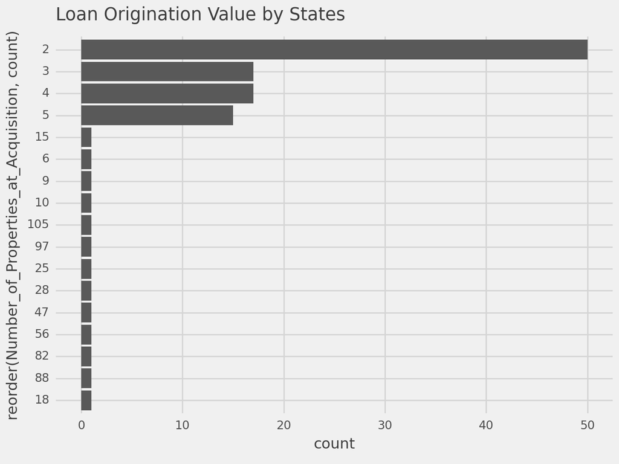

```
<Figure Size: (640 x 480)>
```

```python
(
ggplot(data =
    mf_df_scan4
    .filter(pl.col('Acquisition Date') >= dt.date(2017,1,1))
    .select('Loan Number','Number of Properties at Acquisition')
    .unique()
    .with_columns(pl.col('Number of Properties at Acquisition').cast(pl.Int32))
    .groupby('Number of Properties at Acquisition')
    .count()
    .sort(by = 'count', descending=True, nulls_last=True)
    .rename({"Number of Properties at Acquisition":"Number_of_Properties_at_Acquisition"})
    .filter((pl.col('Number_of_Properties_at_Acquisition').is_not_null()) &
            (pl.col('Number_of_Properties_at_Acquisition') > pl.lit(1))
            )
    .collect()
    ,
    mapping = aes(x = 'reorder(Number_of_Properties_at_Acquisition, count)',
                  y = "count")
                  )
    + geom_col()
    + coord_flip()
    # + geom_jitter()
    + theme_538()
    # + theme(legend_position="none",
    #         figure_size=(8, 15))
    + labs(title = "Loan Origination Value by States")
)
```

### Single Family

```python
sf_scan = pl.scan_csv(r'Single-Family Loan Performance Data\HARP_Files\HARPLPPub.csv',try_parse_dates=True)
sf_scan
```

NAIVE QUERY PLAN

run **LazyFrame.show_graph()** to see the optimized version

```python
sf_scan.schema
```

```
{'|100001565398|082012|R|Quicken Loans Inc.|Quicken Loans Inc.||4.375|4.375|153000.00||0.00|360|072012|092012|0|360|359|082042|138|138|1||700||N|R|SF|1|I|FL|29460|347||FRM|N|N|||00||N||||||||||||||||||||||||||||||||N|||||7||N||||||N||||||||||||||||N|||||': Utf8}
```

```python
sf_scan.head().collect()
```

shape: (5, 1)

| \|100001565398\|082012\|R\|Quicken Loans Inc.\|Quicken Loans Inc.\|\|4.375\|4.375\|153000.00\|\|0.00\|360\|072012\|092012\|0\|360\|359\|082042\|138\|138\|1\|\|700\|\|N\|R\|SF\|1\|I\|FL\|29460\|347\|\|… str |
| --- |
| "\|100001565398\|… |
| "\|100001565398\|… |
| "\|100001565398\|… |
| "\|100001565398\|… |
| "\|100001565398\|… |

```python
sf_scan.select(pl.count()).collect()
```

shape: (1, 1)

| count u32 |
| --- |
| 83405701 |

```python
sf_scan = pl.scan_csv(r'Single-Family Loan Performance Data\HARP_Files\HARPLPPub.csv',try_parse_dates=True, separator="|")
sf_scan
```

NAIVE QUERY PLAN

run **LazyFrame.show_graph()** to see the optimized version

```python
%%timeit
sf_scan.select(pl.count()).collect()
```

```
54.7 s ± 10.9 s per loop (mean ± std. dev. of 7 runs, 1 loop each)
```

```python
sf_scan.select(pl.count()).collect()
```

shape: (1, 1)

| count u32 |
| --- |
| 83405701 |

```python
sf_scan.select(pl.count('100001565398')).collect()
```

shape: (1, 1)

| 100001565398 u32 |
| --- |
| 83405701 |

```python
sf_scan.head().collect()
```

shape: (5, 107)

| str | 100001565398 i64 | 082012 i64 | R str | Quicken Loans Inc. str | Quicken Loans Inc._duplicated_0 str | _duplicated_0 str | 4.375 f64 | 4.375_duplicated_0 f64 | 153000.00 f64 | _duplicated_1 str | 0.00 f64 | 360 i64 | 072012 i64 | 092012 i64 | 0 i64 | 360_duplicated_0 i64 | 359 i64 | 082042 i64 | 138 i64 | 138_duplicated_0 i64 | 1 i64 | _duplicated_2 str | 700 i64 | _duplicated_3 i64 | N str | R_duplicated_0 str | SF str | 1_duplicated_0 i64 | I str | … |
| --- | --- | --- | --- | --- | --- | --- | --- | --- | --- | --- | --- | --- | --- | --- | --- | --- | --- | --- | --- | --- | --- | --- | --- | --- | --- | --- | --- | --- | --- | --- |
| null | 100001565398 | 92012 | "R" | "Quicken Loans … | "Other" | null | 4.375 | 4.375 | 153000.0 | null | 0.0 | 360 | 72012 | 92012 | 1 | 359 | 359 | 82042 | 138 | 138 | 1 | null | 700 | null | "N" | "R" | "SF" | 1 | "I" | … |
| null | 100001565398 | 102012 | "R" | "Quicken Loans … | "Other" | null | 4.375 | 4.375 | 153000.0 | null | 0.0 | 360 | 72012 | 92012 | 2 | 358 | 358 | 82042 | 138 | 138 | 1 | null | 700 | null | "N" | "R" | "SF" | 1 | "I" | … |
| null | 100001565398 | 112012 | "R" | "Quicken Loans … | "Other" | null | 4.375 | 4.375 | 153000.0 | null | 0.0 | 360 | 72012 | 92012 | 3 | 357 | 357 | 82042 | 138 | 138 | 1 | null | 700 | null | "N" | "R" | "SF" | 1 | "I" | … |
| null | 100001565398 | 122012 | "R" | "Quicken Loans … | "Other" | null | 4.375 | 4.375 | 153000.0 | null | 0.0 | 360 | 72012 | 92012 | 4 | 356 | 356 | 82042 | 138 | 138 | 1 | null | 700 | null | "N" | "R" | "SF" | 1 | "I" | … |
| null | 100001565398 | 12013 | "R" | "Quicken Loans … | "Fannie Mae/Set… | null | 4.375 | 4.375 | 153000.0 | null | 0.0 | 360 | 72012 | 92012 | 5 | 355 | 355 | 82042 | 138 | 138 | 1 | null | 700 | null | "N" | "R" | "SF" | 1 | "I" | … |

```python
sf_scan.filter(pl.col('100001565398') == 100007365142).collect()
```

shape: (0, 107)

|  | 100001565398 | 082012 | R | Quicken Loans Inc. | Quicken Loans Inc._duplicated_0 | _duplicated_0 | 4.375 | 4.375_duplicated_0 | 153000.00 | _duplicated_1 | 0.00 | 360 | 072012 | 092012 | 0 | 360_duplicated_0 | 359 | 082042 | 138 | 138_duplicated_0 | 1 | _duplicated_2 | 700 | _duplicated_3 | N | R_duplicated_0 | SF | 1_duplicated_0 | I | … |
| --- | --- | --- | --- | --- | --- | --- | --- | --- | --- | --- | --- | --- | --- | --- | --- | --- | --- | --- | --- | --- | --- | --- | --- | --- | --- | --- | --- | --- | --- | --- |
| str | i64 | i64 | str | str | str | str | f64 | f64 | f64 | str | f64 | i64 | i64 | i64 | i64 | i64 | i64 | i64 | i64 | i64 | i64 | str | i64 | i64 | str | str | str | i64 | str | … |

```python
sf_scan.select(pl.col('Quicken Loans Inc.').unique()).collect()
```

shape: (45, 1)

| Quicken Loans Inc. str |
| --- |
| "Fifth Third Ba… |
| "U.S. Bank N.A.… |
| "PNC Bank, N.A.… |
| "TIAA, FSB" |
| "Tiaa, Fsb" |
| "Newrez Llc" |
| "Rocket Mortgag… |
| "The Huntington… |
| "Ally Bank" |
| "Wells Fargo Ba… |
| "Gmac Mortgage,… |
| "Suntrust Mortg… |
| … |
| "Loandepot.Com,… |
| "Cit Bank, Nati… |
| "New Penn Finan… |
| "Nationstar Mor… |
| "GMAC Mortgage,… |
| "Flagstar Capit… |
| "Ditech Financi… |
| "Bank Of Americ… |
| "Fremont Bank" |
| "E Mortgage Man… |
| "Fifth Third Ba… |
| "Lakeview Loan … |

```python
type(sf_scan.select(pl.col('Quicken Loans Inc.').unique()).head().collect())
```

```
polars.dataframe.frame.DataFrame
```

```python
sf_scan.select(pl.col('Quicken Loans Inc.').unique()).collect().to_series().to_list()
```

```
['Newrez Llc',
 'Bank of America, N.A.',
 'Gmac Mortgage, Llc',
 'Citimortgage, Inc.',
 'JPMorgan Chase Bank, National Association',
 'Lakeview Loan Servicing, Llc',
 'Quicken Loans, LLC',
 'Suntrust Bank',
 'Cit Bank, National Association',
 'Tiaa, Fsb',
 'Ditech Financial LLC',
 'Fremont Bank',
 'U.S. Bank N.A.',
 'Phh Mortgage Corporation',
 'Nationstar Mortgage, Llc',
 'Rocket Mortgage, LLC',
 'Ditech Financial Llc',
 'E Mortgage Management Llc',
 'CitiMortgage, Inc.',
 'Homeward Residential, Inc.',
 'Truist Bank (formerly SunTrust Bank)',
 'Everbank',
 'The Huntington National Bank',
 'GMAC Mortgage, LLC',
 'Ally Bank',
 'Fifth Third Bank, National Association',
 'Flagstar Capital Markets Corporation',
 'PNC Bank, N.A.',
 'Pnc Bank, N.A.',
 'Suntrust Mortgage Inc.',
 'Other',
 'NationStar Mortgage, LLC',
 'TIAA, FSB',
 'Amtrust Bank',
 'Metlife Home Loans Llc',
 'Flagstar Bank, Fsb',
 'Wells Fargo Bank, N.A.',
 'Jpmorgan Chase Bank, National Association',
 'New Penn Financial, Llc Dba Shellpoint Mortgage Servicing',
 'Homestreet Bank',
 'Loandepot.Com, Llc',
 'Fifth Third Bank',
 'Bank Of America, N.A.',
 'Quicken Loans Inc.',
 'Paramount Equity Mortgage, Llc']
```

```python
sf_scan.select(pl.col('Quicken Loans Inc.').n_unique()).collect()
```

shape: (1, 1)

| Quicken Loans Inc. u32 |
| --- |
| 45 |

```python
sf_scan.filter(pl.col('Quicken Loans Inc.').str.contains(r"Fifth Third.*")).head().collect()
```

shape: (5, 107)

| str | 100001565398 i64 | 082012 i64 | R str | Quicken Loans Inc. str | Quicken Loans Inc._duplicated_0 str | _duplicated_0 str | 4.375 f64 | 4.375_duplicated_0 f64 | 153000.00 f64 | _duplicated_1 str | 0.00 f64 | 360 i64 | 072012 i64 | 092012 i64 | 0 i64 | 360_duplicated_0 i64 | 359 i64 | 082042 i64 | 138 i64 | 138_duplicated_0 i64 | 1 i64 | _duplicated_2 str | 700 i64 | _duplicated_3 i64 | N str | R_duplicated_0 str | SF str | 1_duplicated_0 i64 | I str | … |
| --- | --- | --- | --- | --- | --- | --- | --- | --- | --- | --- | --- | --- | --- | --- | --- | --- | --- | --- | --- | --- | --- | --- | --- | --- | --- | --- | --- | --- | --- | --- |
| null | 100145279171 | 32012 | "R" | "Fifth Third Ba… | "Fifth Third Ba… | null | 3.0 | 3.0 | 158000.0 | null | 0.0 | 180 | 32012 | 52012 | -1 | 181 | 180 | 42027 | 90 | 90 | 1 | null | 799 | null | "N" | "R" | "SF" | 1 | "P" | … |
| null | 100145279171 | 42012 | "R" | "Fifth Third Ba… | "Other" | null | 3.0 | 3.0 | 158000.0 | null | 0.0 | 180 | 32012 | 52012 | 0 | 180 | 180 | 42027 | 90 | 90 | 1 | null | 799 | null | "N" | "R" | "SF" | 1 | "P" | … |
| null | 100145279171 | 52012 | "R" | "Fifth Third Ba… | "Other" | null | 3.0 | 3.0 | 158000.0 | null | 0.0 | 180 | 32012 | 52012 | 1 | 179 | 179 | 42027 | 90 | 90 | 1 | null | 799 | null | "N" | "R" | "SF" | 1 | "P" | … |
| null | 100145279171 | 62012 | "R" | "Fifth Third Ba… | "Other" | null | 3.0 | 3.0 | 158000.0 | null | 0.0 | 180 | 32012 | 52012 | 2 | 178 | 178 | 42027 | 90 | 90 | 1 | null | 799 | null | "N" | "R" | "SF" | 1 | "P" | … |
| null | 100145279171 | 72012 | "R" | "Fifth Third Ba… | "Fifth Third Ba… | null | 3.0 | 3.0 | 158000.0 | null | 0.0 | 180 | 32012 | 52012 | 3 | 177 | 151 | 42027 | 90 | 90 | 1 | null | 799 | null | "N" | "R" | "SF" | 1 | "P" | … |

```python
%%timeit
sf_scan.filter(pl.col('Quicken Loans Inc.').str.contains(r"Fifth Third.*")).head().collect()
```

```
1min 41s ± 9.22 s per loop (mean ± std. dev. of 7 runs, 1 loop each)
```

```python
(sf_scan
 .select(pl.col('Quicken Loans Inc.'))
 .filter(pl.col('Quicken Loans Inc.').str.contains(r"Fifth Third.*"))
 .select(pl.count())
 .collect()
 )
```

shape: (1, 1)

| count u32 |
| --- |
| 422255 |

```python
(
    sf_scan
    .select(pl.col('Quicken Loans Inc.').value_counts())
    .collect()
    .to_dict()
)
```

```
{'Quicken Loans Inc.': shape: (45,)
 Series: 'Quicken Loans Inc.' [struct[2]]
 [
 	{"JPMorgan Chase Bank, National Association",1896502}
 	{"Ally Bank",1784923}
 	{"Newrez Llc",2022}
 	{"Loandepot.Com, Llc",67080}
 	{"CitiMortgage, Inc.",753489}
 	{"Truist Bank (formerly SunTrust Bank)",449072}
 	{"Fremont Bank",4789}
 	{"Ditech Financial Llc",2313601}
 	{"Phh Mortgage Corporation",250917}
 	{"Fifth Third Bank, National Association",116341}
 	{"Everbank",649402}
 	{"Gmac Mortgage, Llc",1512437}
 	…
 	{"GMAC Mortgage, LLC",142818}
 	{"Suntrust Bank",29924}
 	{"Tiaa, Fsb",36241}
 	{"Wells Fargo Bank, N.A.",12825668}
 	{"Jpmorgan Chase Bank, National Association",12372032}
 	{"Suntrust Mortgage Inc.",2393939}
 	{"PNC Bank, N.A.",241644}
 	{"Bank of America, N.A.",1324639}
 	{"E Mortgage Management Llc",10798}
 	{"Homestreet Bank",8931}
 	{"Bank Of America, N.A.",9200549}
 	{"Ditech Financial LLC",602574}
 	{"Nationstar Mortgage, Llc",1339443}
 ]}
```

```python
print(
    sf_scan
    .filter(pl.col('Quicken Loans Inc.').str.contains(r"Fifth Third.*"))
    .groupby('Quicken Loans Inc.','Quicken Loans Inc._duplicated_0')
    .count()
    .sort('count', descending=True)
    .collect()

)
```

```
shape: (7, 3)
┌───────────────────────────────────┬───────────────────────────────────┬────────┐
│ Quicken Loans Inc.                ┆ Quicken Loans Inc._duplicated_0   ┆ count  │
│ ---                               ┆ ---                               ┆ ---    │
│ str                               ┆ str                               ┆ u32    │
╞═══════════════════════════════════╪═══════════════════════════════════╪════════╡
│ Fifth Third Bank                  ┆ Other                             ┆ 179136 │
│ Fifth Third Bank                  ┆ Fifth Third Bank                  ┆ 114596 │
│ Fifth Third Bank, National Assoc… ┆ Fifth Third Bank, National Assoc… ┆ 111880 │
│ Fifth Third Bank                  ┆ Fifth Third Bank, National Assoc… ┆ 9446   │
│ Fifth Third Bank                  ┆ null                              ┆ 2736   │
│ Fifth Third Bank, National Assoc… ┆ null                              ┆ 2352   │
│ Fifth Third Bank, National Assoc… ┆ PNC Bank, N.A.                    ┆ 2109   │
└───────────────────────────────────┴───────────────────────────────────┴────────┘
```

```python
print(
    sf_scan
    # filter(pl.col('Quicken Loans Inc.').str.contains(r"Fifth Third.*"))
    .groupby('Quicken Loans Inc.','Quicken Loans Inc._duplicated_0')
    .count()
    .sort('count', descending=True)
    .collect()

)
```

```
shape: (364, 3)
┌───────────────────────────────────┬───────────────────────────────────┬──────────┐
│ Quicken Loans Inc.                ┆ Quicken Loans Inc._duplicated_0   ┆ count    │
│ ---                               ┆ ---                               ┆ ---      │
│ str                               ┆ str                               ┆ u32      │
╞═══════════════════════════════════╪═══════════════════════════════════╪══════════╡
│ Other                             ┆ Other                             ┆ 13619494 │
│ Wells Fargo Bank, N.A.            ┆ Wells Fargo Bank, N.A.            ┆ 12686808 │
│ Jpmorgan Chase Bank, National As… ┆ Jp Morgan Chase Bank, Na          ┆ 10845919 │
│ Bank Of America, N.A.             ┆ Bank Of America, N.A.             ┆ 8208851  │
│ …                                 ┆ …                                 ┆ …        │
│ Newrez Llc                        ┆ null                              ┆ 5        │
│ Ditech Financial LLC              ┆ Truist Bank (formerly SunTrust B… ┆ 3        │
│ The Huntington National Bank      ┆ Central Mortgage Company          ┆ 3        │
│ Phh Mortgage Corporation          ┆ Fannie Mae/Nationstar As Subserv… ┆ 2        │
└───────────────────────────────────┴───────────────────────────────────┴──────────┘
```

```python
sf_scan.collect().write_parquet('single_family_vscode_to_r.parquet')
```

```python
sf_head = pl.read_csv(r'Single-Family Loan Performance Data\HARP_Files\HARPLPPub.csv',n_rows=10, separator="|", try_parse_dates=True)
sf_head
```

shape: (10, 107)

| str | 100001565398 i64 | 082012 i64 | R str | Quicken Loans Inc. str | Quicken Loans Inc._duplicated_0 str | _duplicated_0 str | 4.375 f64 | 4.375_duplicated_0 f64 | 153000.00 f64 | _duplicated_1 str | 0.00 f64 | 360 i64 | 072012 i64 | 092012 i64 | 0 i64 | 360_duplicated_0 i64 | 359 i64 | 082042 i64 | 138 i64 | 138_duplicated_0 i64 | 1 i64 | _duplicated_2 str | 700 i64 | _duplicated_3 i64 | N str | R_duplicated_0 str | SF str | 1_duplicated_0 i64 | I str | … |
| --- | --- | --- | --- | --- | --- | --- | --- | --- | --- | --- | --- | --- | --- | --- | --- | --- | --- | --- | --- | --- | --- | --- | --- | --- | --- | --- | --- | --- | --- | --- |
| null | 100001565398 | 92012 | "R" | "Quicken Loans … | "Other" | null | 4.375 | 4.375 | 153000.0 | null | 0.0 | 360 | 72012 | 92012 | 1 | 359 | 359 | 82042 | 138 | 138 | 1 | null | 700 | null | "N" | "R" | "SF" | 1 | "I" | … |
| null | 100001565398 | 102012 | "R" | "Quicken Loans … | "Other" | null | 4.375 | 4.375 | 153000.0 | null | 0.0 | 360 | 72012 | 92012 | 2 | 358 | 358 | 82042 | 138 | 138 | 1 | null | 700 | null | "N" | "R" | "SF" | 1 | "I" | … |
| null | 100001565398 | 112012 | "R" | "Quicken Loans … | "Other" | null | 4.375 | 4.375 | 153000.0 | null | 0.0 | 360 | 72012 | 92012 | 3 | 357 | 357 | 82042 | 138 | 138 | 1 | null | 700 | null | "N" | "R" | "SF" | 1 | "I" | … |
| null | 100001565398 | 122012 | "R" | "Quicken Loans … | "Other" | null | 4.375 | 4.375 | 153000.0 | null | 0.0 | 360 | 72012 | 92012 | 4 | 356 | 356 | 82042 | 138 | 138 | 1 | null | 700 | null | "N" | "R" | "SF" | 1 | "I" | … |
| null | 100001565398 | 12013 | "R" | "Quicken Loans … | "Fannie Mae/Set… | null | 4.375 | 4.375 | 153000.0 | null | 0.0 | 360 | 72012 | 92012 | 5 | 355 | 355 | 82042 | 138 | 138 | 1 | null | 700 | null | "N" | "R" | "SF" | 1 | "I" | … |
| null | 100001565398 | 22013 | "R" | "Quicken Loans … | "Fannie Mae/Set… | null | 4.375 | 4.375 | 153000.0 | null | 151256.13 | 360 | 72012 | 92012 | 6 | 354 | 354 | 82042 | 138 | 138 | 1 | null | 700 | null | "N" | "R" | "SF" | 1 | "I" | … |
| null | 100001565398 | 32013 | "R" | "Quicken Loans … | "Fannie Mae/Set… | null | 4.375 | 4.375 | 153000.0 | null | 151046.16 | 360 | 72012 | 92012 | 7 | 353 | 353 | 82042 | 138 | 138 | 1 | null | 700 | null | "N" | "R" | "SF" | 1 | "I" | … |
| null | 100001565398 | 42013 | "R" | "Quicken Loans … | "Fannie Mae/Set… | null | 4.375 | 4.375 | 153000.0 | null | 150835.43 | 360 | 72012 | 92012 | 8 | 352 | 352 | 82042 | 138 | 138 | 1 | null | 700 | null | "N" | "R" | "SF" | 1 | "I" | … |
| null | 100001565398 | 52013 | "R" | "Quicken Loans … | "Fannie Mae/Set… | null | 4.375 | 4.375 | 153000.0 | null | 150623.93 | 360 | 72012 | 92012 | 9 | 351 | 351 | 82042 | 138 | 138 | 1 | null | 700 | null | "N" | "R" | "SF" | 1 | "I" | … |
| null | 100001565398 | 62013 | "R" | "Quicken Loans … | "Fannie Mae/Set… | null | 4.375 | 4.375 | 153000.0 | null | 150411.66 | 360 | 72012 | 92012 | 10 | 350 | 350 | 82042 | 138 | 138 | 1 | null | 700 | null | "N" | "R" | "SF" | 1 | "I" | … |

```python
sf_head.columns
```

```
['',
 '100001565398',
 '082012',
 'R',
 'Quicken Loans Inc.',
 'Quicken Loans Inc._duplicated_0',
 '_duplicated_0',
 '4.375',
 '4.375_duplicated_0',
 '153000.00',
 '_duplicated_1',
 '0.00',
 '360',
 '072012',
 '092012',
 '0',
 '360_duplicated_0',
 '359',
 '082042',
 '138',
 '138_duplicated_0',
 '1',
 '_duplicated_2',
 '700',
 '_duplicated_3',
 'N',
 'R_duplicated_0',
 'SF',
 '1_duplicated_0',
 'I',
 'FL',
 '29460',
 '347',
 '_duplicated_4',
 'FRM',
 'N_duplicated_0',
 'N_duplicated_1',
 '_duplicated_5',
 '_duplicated_6',
 '00',
```

[output cut: 52 more lines]

```
 '_duplicated_54',
 '_duplicated_55',
 '_duplicated_56',
 '_duplicated_57',
 '_duplicated_58',
 '_duplicated_59',
 '_duplicated_60',
 '_duplicated_61',
 '_duplicated_62',
 '_duplicated_63',
 'N_duplicated_6',
 '_duplicated_64',
 '_duplicated_65',
 '_duplicated_66',
 '_duplicated_67']
```

```python
sf_head.columns.__len__()
```

```
107
```

Single Family 2022 Q1

```python
sf_2022_q1_scan =  pl.scan_csv(r'Single-Family Loan Performance Data\2022Q1\2022Q1.csv', try_parse_dates=True, ignore_errors=True)
```

```python
sf_2022_q1_scan.head().collect()
```

shape: (5, 2)

| \|000130357804\|012022\|R\|Other\|Lakeview Loan Servicing str | LLC\|\|3.375\|3.375\|255000.00\|\|255000.00\|360\|012022\|032022\|-1\|361\|360\|022052\|72\|72\|1\|43\|703\|\|N\|P\|SF\|1\|P\|NV\|29820\|891\|\|FRM\|N\|N\|\|\|00\|XXXXXXXXXXXXXXXXXXXXXXXXXXXXXXXXXXXXX… str |
| --- | --- |
| "\|000130357804\|… | " LLC\|\|3.375\|3.… |
| "\|000130357804\|… | " LLC\|\|3.375\|3.… |
| "\|000130357804\|… | " LLC\|\|3.375\|3.… |
| "\|000130357804\|… | " LLC\|\|3.375\|3.… |
| "\|000130357804\|… | " LLC\|\|3.375\|3.… |

```python
sf_2022_q1_scan =  pl.scan_csv(r'Single-Family Loan Performance Data\2022Q1\2022Q1.csv',
                               try_parse_dates=True, ignore_errors=True, separator="|")

sf_2022_q1_scan.head().collect()
```

shape: (5, 107)

| str | 000130357804 i64 | 012022 i64 | R str | Other str | Lakeview Loan Servicing, LLC str | _duplicated_0 str | 3.375 f64 | 3.375_duplicated_0 f64 | 255000.00 f64 | _duplicated_1 str | 255000.00_duplicated_0 f64 | 360 i64 | 012022_duplicated_0 i64 | 032022 i64 | -1 i64 | 361 i64 | 360_duplicated_0 i64 | 022052 i64 | 72 i64 | 72_duplicated_0 i64 | 1 i64 | 43 i64 | 703 i64 | _duplicated_2 i64 | N str | P str | SF str | 1_duplicated_0 i64 | P_duplicated_0 str | … |
| --- | --- | --- | --- | --- | --- | --- | --- | --- | --- | --- | --- | --- | --- | --- | --- | --- | --- | --- | --- | --- | --- | --- | --- | --- | --- | --- | --- | --- | --- | --- |
| null | 130357804 | 22022 | "R" | "Other" | "Lakeview Loan … | null | 3.375 | 3.375 | 255000.0 | null | 255000.0 | 360 | 12022 | 32022 | 0 | 360 | 360 | 22052 | 72 | 72 | 1 | 43 | 703 | null | "N" | "P" | "SF" | 1 | "P" | … |
| null | 130357804 | 32022 | "R" | "Other" | "Lakeview Loan … | null | 3.375 | 3.375 | 255000.0 | null | 255000.0 | 360 | 12022 | 32022 | 1 | 359 | 359 | 22052 | 72 | 72 | 1 | 43 | 703 | null | "N" | "P" | "SF" | 1 | "P" | … |
| null | 130357804 | 42022 | "R" | "Other" | "Lakeview Loan … | null | 3.375 | 3.375 | 255000.0 | null | 254000.0 | 360 | 12022 | 32022 | 2 | 358 | 358 | 22052 | 72 | 72 | 1 | 43 | 703 | null | "N" | "P" | "SF" | 1 | "P" | … |
| null | 130357804 | 52022 | "R" | "Other" | "Lakeview Loan … | null | 3.375 | 3.375 | 255000.0 | null | 254000.0 | 360 | 12022 | 32022 | 3 | 357 | 357 | 22052 | 72 | 72 | 1 | 43 | 703 | null | "N" | "P" | "SF" | 1 | "P" | … |
| null | 130357804 | 62022 | "R" | "Other" | "Lakeview Loan … | null | 3.375 | 3.375 | 255000.0 | null | 253000.0 | 360 | 12022 | 32022 | 4 | 356 | 356 | 22052 | 72 | 72 | 1 | 43 | 703 | null | "N" | "P" | "SF" | 1 | "P" | … |

## Lending Club Data

```python
LC_scan = pl.scan_csv(r'V:\Credit Risk Modeling Lending Club data\archive\accepted_2007_to_2018q4.csv\accepted_2007_to_2018Q4.csv')
```

```python
LC_scan.head().collect()
```

shape: (5, 151)

| id i64 | member_id str | loan_amnt f64 | funded_amnt f64 | funded_amnt_inv f64 | term str | int_rate f64 | installment f64 | grade str | sub_grade str | emp_title str | emp_length str | home_ownership str | annual_inc f64 | verification_status str | issue_d str | loan_status str | pymnt_plan str | url str | desc str | purpose str | title str | zip_code str | addr_state str | dti f64 | delinq_2yrs f64 | earliest_cr_line str | fico_range_low f64 | fico_range_high f64 | inq_last_6mths f64 | … |
| --- | --- | --- | --- | --- | --- | --- | --- | --- | --- | --- | --- | --- | --- | --- | --- | --- | --- | --- | --- | --- | --- | --- | --- | --- | --- | --- | --- | --- | --- | --- |
| 68407277 | null | 3600.0 | 3600.0 | 3600.0 | " 36 months" | 13.99 | 123.03 | "C" | "C4" | "leadman" | "10+ years" | "MORTGAGE" | 55000.0 | "Not Verified" | "Dec-2015" | "Fully Paid" | "n" | "https://lendin… | null | "debt_consolida… | "Debt consolida… | "190xx" | "PA" | 5.91 | 0.0 | "Aug-2003" | 675.0 | 679.0 | 1.0 | … |
| 68355089 | null | 24700.0 | 24700.0 | 24700.0 | " 36 months" | 11.99 | 820.28 | "C" | "C1" | "Engineer" | "10+ years" | "MORTGAGE" | 65000.0 | "Not Verified" | "Dec-2015" | "Fully Paid" | "n" | "https://lendin… | null | "small_business… | "Business" | "577xx" | "SD" | 16.06 | 1.0 | "Dec-1999" | 715.0 | 719.0 | 4.0 | … |
| 68341763 | null | 20000.0 | 20000.0 | 20000.0 | " 60 months" | 10.78 | 432.66 | "B" | "B4" | "truck driver" | "10+ years" | "MORTGAGE" | 63000.0 | "Not Verified" | "Dec-2015" | "Fully Paid" | "n" | "https://lendin… | null | "home_improveme… | null | "605xx" | "IL" | 10.78 | 0.0 | "Aug-2000" | 695.0 | 699.0 | 0.0 | … |
| 66310712 | null | 35000.0 | 35000.0 | 35000.0 | " 60 months" | 14.85 | 829.9 | "C" | "C5" | "Information Sy… | "10+ years" | "MORTGAGE" | 110000.0 | "Source Verifie… | "Dec-2015" | "Current" | "n" | "https://lendin… | null | "debt_consolida… | "Debt consolida… | "076xx" | "NJ" | 17.06 | 0.0 | "Sep-2008" | 785.0 | 789.0 | 0.0 | … |
| 68476807 | null | 10400.0 | 10400.0 | 10400.0 | " 60 months" | 22.45 | 289.91 | "F" | "F1" | "Contract Speci… | "3 years" | "MORTGAGE" | 104433.0 | "Source Verifie… | "Dec-2015" | "Fully Paid" | "n" | "https://lendin… | null | "major_purchase… | "Major purchase… | "174xx" | "PA" | 25.37 | 1.0 | "Jun-1998" | 695.0 | 699.0 | 3.0 | … |